# 28.Dönem Cumhurbaşkanlığı ve Milletvekilliği Seçim Analizi

## Giriş

2023 milletvekili genel seçimlerinde İzmir 1. Bölge parlamentoya on dört milletvekili gönderecek. 2018’de gerçekleşen seçimlerde CHP yedi, AK Parti dört, MHP bir ve HDP bir milletvekili elde etmişti. 2023 seçimlerine giderken Türkiye genelinde olduğu gibi İzmir 1. Bölgede de siyasi aritmetiğin değiştiği aşikardır. Raporda, 2015 Kasım, 2018 Cumhurbaşkanlığı ve milletvekili seçimlerinin sonuçları il geneli ve mahalle bazlı incelenerek, geçmiş sonuçların siyasi aritmetiğine dair mikro ölçekte vereceği ipuçları derlenecek ve analiz edilecektir. Türkiye geneli için yapılan milletvekili seçim anketlerinin aritmetik yöntem ile hesaplanması ve geçmiş verilerin incelenmesiyle birlikte İzmir 1. Bölge için muhtemel milletvekili dağılımı, partilerin ve ittifakların oy oranlarına dair simülasyonlar oluşturulacaktır. Oluşturulan simülasyonlar neticesinde CHP’nin 2018 genel seçimlerinde İzmir 1. Bölge ortalamasının ve Türkiye ortalamasının üzerinde ve/veya gerisinde oy aldığı mahalleler tespit edilecektir. 2023 seçimleri sürecinde İzmir 1. Bölge ölçeğinde CHP adına yapılacak saha çalışmalarının yoğunlaşması gereken mahalleler/bölgeler tespit edilecektir. Çalışmanın temel amacı sahada en az enerji ile maksimum oy faydasını elde etmektir. İlk olarak son iki genel seçimde İzmir 1. Bölge’deki oy oranlarını hatırlamak, Cumhurbaşkanlığı seçimlerindeki oy geçişlerini analiz etmek ve bugün için beklenen sonuçları değerlendirmek gerekir.

Aşağıdaki grafik 2015 Kasım ve 2018 genel seçimlerinde partilerin İzmir 1. Bölge oy oranlarını göstermektedir.

### İzmir 1. Bölge Kasım 2015 ve 2018 Genel Seçim Sonuçları

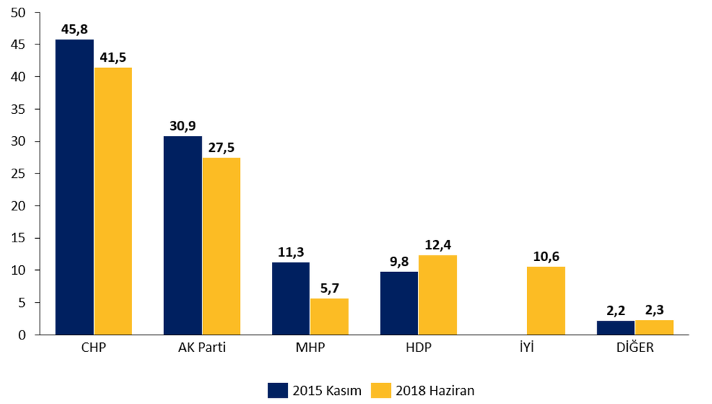

2015 Kasım seçimleri ile 2018 seçimleri arasında AK Parti, CHP ve MHP’de oy kayıpları yaşanırken HDP’de oy artışı olmuştur.

• MHP yüzde 5,6 oran ile en fazla oy kaybı yaşayan parti olurken, AK Parti yüzde 3,4, CHP ise yüzde 4,3 oranında oy kaybetmiştir.

• Seferihisar, Menderes, Gaziemir, Torbalı ve Buca AK Parti’nin yüzde 4,0’den fazla oy kaybettiği ilçeler olarak öne çıkmaktadır. MHP’nin ise bu ilçelerde oy kaybı daha fazladır. MHP seçmenlerinin İyi Parti’ye geçişi fazla olduğu için MHP’de de ilgili ilçelerde oy kaybı yaşanmıştır.

• CHP ise Narlıdere, Güzelbahçe, Konak, Urla, Balçova, Karaburun ve Çeşme ilçelerinde yüzde 5’den fazla oy kaybetmiştir. İlgili ilçelerde CHP’den İyi Parti’ye yüzde 2,5 civarında oy geçişi tespit edilmiştir.

2018 yılında milletvekili seçimi sonuçlarının yanı sıra Cumhurbaşkanlığı seçimleri de yapıldı. Ortaya çıkan sonuçlar milletvekili seçimlerinden biraz daha farklıydı. Kimi adaylar partilerinden/ittifaklarından fazla oy alırken kimileri ise gerisinde kaldı.

### 2018 Cumhurbaşkanlığı İzmir 1. Bölge Seçim Sonuçları

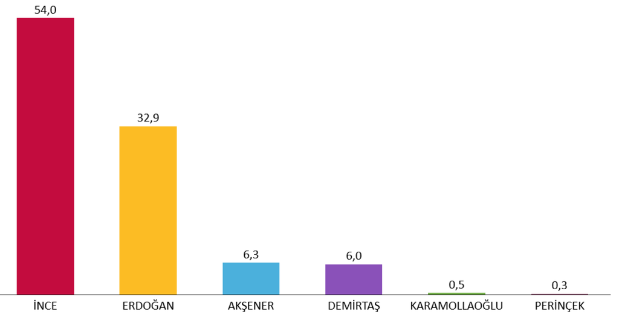

• 6 adaylı Cumhurbaşkanlığı seçimlerinde İzmir 1. Bölge’de Muharrem İnce yüzde 54,0 oy oranı ile en fazla oy alan aday oldu. Erdoğan ise, 2018 yılında yapılan Cumhurbaşkanlığı seçimlerinde yüzde 32,9 oranında oy alarak 2. Parti olmuştu.

• Muhalefet adaylarından Meral Akşener yüzde 6,3, Selahattin Demirtaş yüzde 6,0, Temel Karamollaoğlu yüzde 0,5, Doğu Perinçek ise yüzde 0,3 oranında oy almıştır.

• Recep Tayyip Erdoğan’ı destekleyen AK Parti, MHP ve Hüda-Par’ın milletvekili seçimlerinde İzmir 1. Bölgedeki toplam oyları yüzde 34,0 olmuştur. Erdoğan’ın oyları, destekçi partilerinin yüzde 1,1 gerisinde kalmıştır. Cumhur ittifakı ve Hüda-Par’a oy veren yaklaşık 15.100 seçmen Erdoğan’a oy vermemiştir.

• CHP adayı Muharrem İnce ise partisinden yüzde 12,5 daha fazla oy almıştır. Bu oran Türkiye geneli ile örtüşmektedir. Muharrem İnce’ye parti dışarısından İyi Parti ve HDP’den oy gelmiştir. Muharrem İnce, CHP’den 171.670 oy daha fazla almıştır.

• Selahattin Demirtaş’ın oyları HDP’den yüzde 6,4, Temel Karamollaoğlu’nun oyları Saadet Partisi’nden yüzde 0,3 daha az gerçekleşirken, Doğu Perinçek’in oyları Vatan Partisi’yle aynı gerçekleşmiştir.

2015 Kasım ve 2018 genel seçimlerinde partilerin ilçe bazlı oy dağılımları aşağıdaki tablolarda gösterilmektedir.

### Kasım 2015 İzmir 1. Bölge İlçe Bazlı Milletvekili Seçim Sonuçları

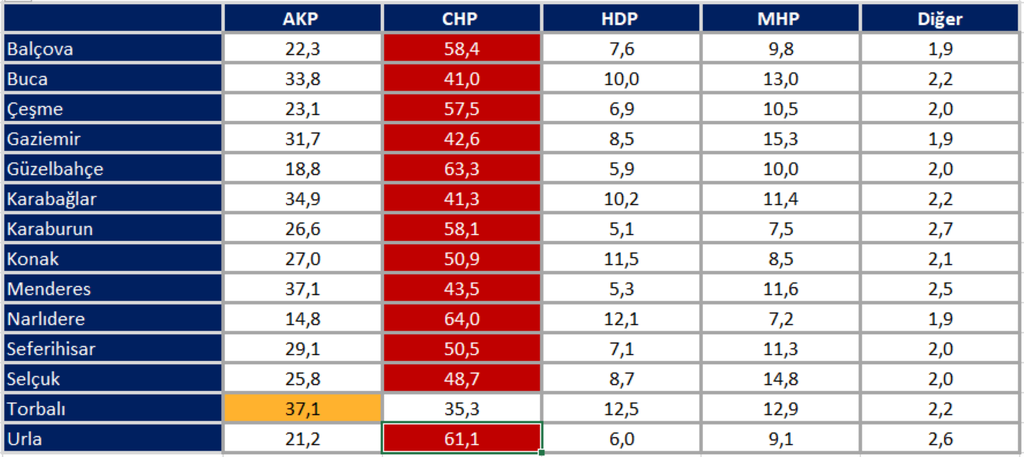

• 2015 Kasım seçimlerinde AK Parti İzmir 1. Bölge’de Gaziemir, Buca, Karabağlar, Menderes ve Torbalı ilçelerinde ildeki bölge ortalamasının üzerinde oy almıştır. İzmir 1. Bölge’de AK Parti’nin en yüksek oy aldığı ilçe yüzde 37,1 ile Torbalı olurken, en düşük oy aldığı ilçe yüzde 14,8 ile Narlıdere olmuştur.

• MHP’de ki oy dağılımına bakıldığında Gaziemir yüzde 15’ten fazla oy aldığı tek ilçe olarak ön plana çıkmaktadır. MHP, Narlıdere, Karaburun, Konak, Urla ve Balçova’da 10,0’un altında kalmıştır.

### 2018 İzmir 1. Bölge İlçe Bazlı Milletvekili Seçim Sonuçları

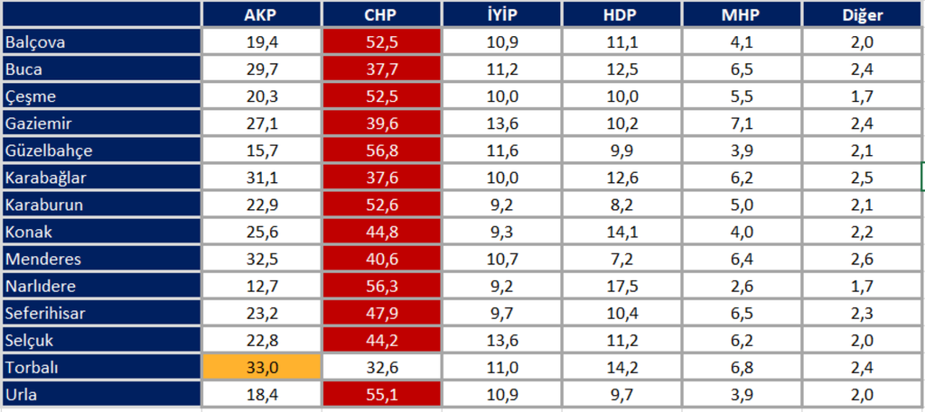

• 2018 genel seçimleri İzmir 1. Bölge genelinde AK Parti, CHP ve MHP’nin oy kaybına sahne oldu.

• AK Parti 2018 seçimlerinde, 2015 Kasım seçimlerine göre bütün ilçelerde oy kaybetmiştir. En fazla oy kaybettiği beş ilçe olan Buca, Gaziemir, Menderes, Torbalı ve Seferihisar’da her bir ilçe için oy kaybı yüzde 4,0’ün üzerindedir.

• CHP’de AK Parti’ye benzer şekilde bütün ilçelerde oy kaybetmiş olup, en fazla oy kaybettiği ilçeler ise Güzelbahçe, Narlıdere, Urla ve Konak’tır. Menderes, Torbalı ve Seferihisar ilçeleri ise diğer ilçelere nazaran daha az oy kaybı yaşanan ilçeler olarak öne çıkmakta olup, üç ilçede ortalama kayıp yüzde 2,7’dir.

• İzmir 1. Bölge’nin tüm ilçelerinde MHP’de oylarını kaybetmiştir. Selçuk ve Gaziemir ilçeleri MHP’nin yüzde 8,0’in üzerinde oy kaybettiği ilçelerdir. Karaburun ilçesinde MHP yüzde 2,5 oranında diğer ilçelere nazaran kısmi bir düşüş yasamasına rağmen bu durum MHP’nin İzmir 1. Bölgedeki durumunun vahametini göstermektedir.

### 2018 İzmir 1. Bölge İlçe Bazlı Cumhurbaşkanlığı Seçim Sonuçları

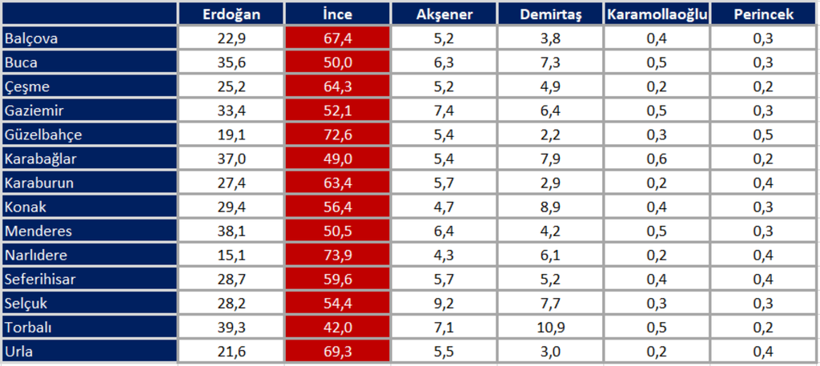

• Erdoğan’ın oyları Buca, Karabağlar, Menderes ve Torbalı ilçelerinde yüzde 35,0’in üstüne ulaşmasına rağmen tüm ilçelerde muhalefet adaylarından Muharrem İnce’nin gerisinde kalmıştır. Narlıdere İlçesi Erdoğan’ın en az oy aldığı ilçe olmakla birlikte Güzelbahçe, Urla, Balçova ve Çeşme ilçeleri İzmir 1. Bölge AK Parti ortalamasının gerisindedir.

• Muharrem İnce’nin oyları İzmir 1. Bölge’de CHP’den yüzde 12,5 daha fazla gerçekleşmiştir. İnce, dokuz ilçede İzmir 1. Bölge ortalamasının üstünde oy almış, Balçova, Urla, Güzelbahçe ve Narlıdere’de ise yüzde 65,0’ten fazla oy almıştır. Torbalı ve Karabağlar’da ise İnce, yüzde 50,0’yi aşamamıştır.

• Meral Akşener’in oyları ise İyi Parti’nin 4,3 puan gerisinde kaldı. Akşener, Buca, Menderes, Gaziemir, Torbalı ve Selçuk ilçelerinde yüzde 6,3 olan Cumhurbaşkanlığı seçim oranından yüksek oy almıştır. Yüzde 9,2 ile Selçuk, yüzde 7,4 ile Gaziemir ve yüzde 7,1 ile Torbalı ilçeleri Akşener’in en fazla oy aldığı ilçeler olarak tespit edilmiştir. Diğer yandan, Narlıdere ve Konak ilçeleri ise Akşener’in en düşük oy alarak yüzde 5,0’in altında kalan iki ilçedir.

Nisan 2023 tarihi itibarıyla yapılan genel seçim anketlerinin İzmir 1. Bölge özelinde hesaplanmasıyla beraber ortaya çıkan toplam veriler ile ilçe bazlı beklenen sonuçlar ve muhtemel milletvekili dağılımı aşağıda tablo ve grafiklerde gösterilmektedir.

### İzmir 1. Bölge Genel Seçim Tahminleri, Nisan 2023, %

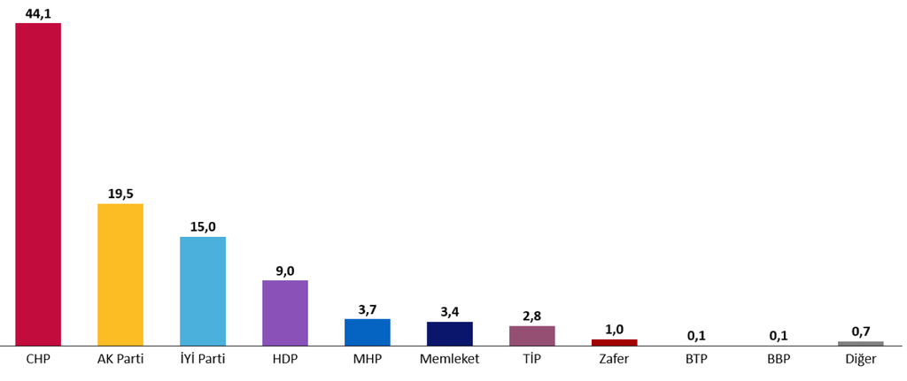

Nisan 2023 itibarıyla CHP’nin İzmir 1. Bölgede birinci parti olması beklenmektedir. 2018 genel seçimlerine göre partilerdeki oy değişimleri incelendiğinde AK Parti’de yüzde 8,0, MHP’de yüzde 2,0, HDP’de yüzde 3,4 oranında oy kaybı yaşanacağı tahmin edilirken. İYİ Parti’nin yüzde 4,4, CHP’nin ise yüzde 2,6 oranında oy artırması beklenmektedir.

Cumhur ittifakı bileşenleri AK Parti ve MHP’de toplamda yüzde 10,0 oranında oy kaybı tahmin edilmektedir. Millet ittifakından CHP ve İyi Parti’de ise yüzde 7,0 oranında oy artışı öngörülmektedir.

Yeni kurulan siyasi partilerden Memleket Partisi yüzde 3,4, Türkiye İşçi Partisi yüzde 2,8, Zafer Partisi ise yüzde 1,0 oy oranına ulaşmaktadır.

### İzmir 1. Bölge İlçe Bazlı Genel Seçim Tahminleri, Nisan 2023

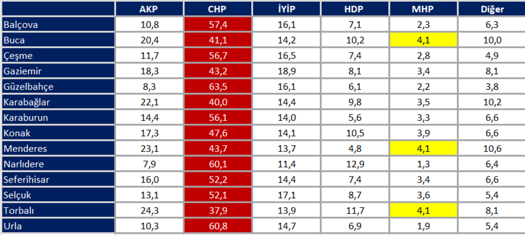

• Mevcut anket verileri ışığında İzmir 1. Bölgede partilerin beklenen oyları tabloda görüldüğü gibidir. Bugün itibarıyla AK Parti’nin birinci parti olması muhtemel görünmemekle birlikte 2023 tahminlerinde İzmir 1. bölgedeki tüm ilçelerde 2018 genel seçimlerine göre oy kaybı yaşanacaktır. AK Parti’de en fazla oy kaybının Selçuk’ta yüzde 9,7, Menderes’te yüzde 9,4, Buca’da yüzde 9,3 ve Karabağlar’da yüzde 9,0 olması beklenmektedir.

• CHP’nin ilçe performansları incelendiğinde tüm ilçelerde oy oranını artıracağı tahmin edilmektedir. Oy oranının en fazla artması beklenen ilçesi yüzde 7,9 ile Selçuk iken, en az artışısın yüzde 2,4 ile Karabağlar’dan olması öngörülmektedir.

• İYİ Parti’nin de tüm ilçelerde oylarını artıracağı tahmin edilmekte, oy potansiyelinin en güçlü olduğu ilçe ise yüzde 6,5 ile Çeşme’dir. Narlıdere ve Torbalı ilçeleri ise sırasıyla yüzde 2,2 ve yüzde 2,9 oran ile İyi Parti’nin oy oranını en az artırabileceği ilçeler olarak değerlendirilmektedir.

• MHP’nin, 2018 seçimlerine göre İzmir 1. bölgedeki tüm ilçelerde oy kaybetmesi beklenmektedir. En fazla oy kaybetmesi beklenen ilçe yüzde 3,7’lik bir kayıpla İyi Parti’nin oy potansiyelinin güçlü olduğu ilçelerden biri olan Gaziemir’dir. Benzer şekilde Seferihisar, Torbalı, Karabağlar, Çeşme ve Selçuk MHP’nin yüzde 2,5’in üzerinde oy kaybı yaşayacağı ilçeler olarak öne çıkmaktadır.

## Parti Bazlı Analizler

İzmir 1. Bölgede siyasi aritmetiği ve geçmişe dönük sonuçları yukarıdaki grafik ve tablolar ile bildirdik. Bundan sonra verilecek haritalar ve tablolar ilçe bazlı partilerin oy dağılımını ve 2023 genel seçimine yönelik sonuçları gösterecektir. AK Parti, CHP, MHP ve İyi Parti’ye dair 2018 genel seçim sonuçlarına ilişkin ilçe bazlı oy dağılımları aşağıda sıralanmıştır.

### AK Parti

#### İlçe Bazlı

[interactive chart not shown]

AK Partinin oyları Karabağlar, Menderes ve Torbalı ilçelerinde yüzde 30,0’un üzerine çıkmaktadır. Bu ilçeler AK Partinin İzmir 1. Bölgede güçlü olduğu alanlar olarak öne çıkmaktadır. Narlıdere, Güzelbahçe, Urla ve Balçova ise AK Partinin en düşük oy aldığı ilçeler olarak göze çarpmaktadır. Narlıdere yüzde 15,0’in altında oy oranı ile Ak Parti’nin en zayıf olduğu ilçedir.

#### Mahalle Bazlı

[interactive chart not shown]

AK Partinin oyları Karabağlar, Menderes ve Torbalı ilçelerinde yüzde 30,0’un üzerine çıkmaktadır. Bu ilçeler AK Partinin İzmir 1. Bölgede güçlü olduğu alanlar olarak öne çıkmaktadır. Narlıdere, Güzelbahçe, Urla ve Balçova ise AK Partinin en düşük oy aldığı ilçeler olarak göze çarpmaktadır. Narlıdere yüzde 15,0’in altında oy oranı ile Ak Parti’nin en zayıf olduğu ilçedir.

### CHP

#### İlçe Bazlı

[interactive chart not shown]

CHP’nin ilçe bazlı oy dağılımı incelendiğinde Torbalı ilçesinde oy oranı yüzde 35,0’in altında kalmaktadır. Bu ilçe CHP’nin oy potansiyelinin en düşük olduğu ilçedir. Cumhuriyet Halk Partisinin İzmir 1. Bölgede yüzde 50’nin üzerine çıktığı ve oy potansiyelinin yüksek olduğu ilçelerin ise Balçova, Çeşme, Karaburun, Urla, Narlıdere ve Güzelbahçe olduğu tespit edilmiştir. 2023 genel seçimlerinde CHP’nin önem vermesi gereken ilçeler Torbalı, Karabağlar, Buca ve Gaziemir olarak tespit edilmiştir.

#### Mahalle Bazlı

[interactive chart not shown]

CHP’nin ilçe bazlı oy dağılımı incelendiğinde Torbalı ilçesinde oy oranı yüzde 35,0’in altında kalmaktadır. Bu ilçe CHP’nin oy potansiyelinin en düşük olduğu ilçedir. Cumhuriyet Halk Partisinin İzmir 1. Bölgede yüzde 50’nin üzerine çıktığı ve oy potansiyelinin yüksek olduğu ilçelerin ise Balçova, Çeşme, Karaburun, Urla, Narlıdere ve Güzelbahçe olduğu tespit edilmiştir. 2023 genel seçimlerinde CHP’nin önem vermesi gereken ilçeler Torbalı, Karabağlar, Buca ve Gaziemir olarak tespit edilmiştir.

### İYİ Parti

#### İlçe Bazlı

[interactive chart not shown]

#### Mahalle Bazlı

[interactive chart not shown]

### MHP

#### İlçe Bazlı

[interactive chart not shown]

#### Mahalle Bazlı

[interactive chart not shown]

### HDP

#### İlçe Bazlı

[interactive chart not shown]

#### Mahalle Bazlı

[interactive chart not shown]

## Partiler Arası Oy Geçişleri Üzerine Analizler

Raporun bu bölümünde İktidar bloğunun oy değişimleri göz önüne alınarak, stratejik öneme sahip mahallelerin tespiti yapılmıştır. Mahalle bazlı CHP’nin potansiyel seçmenlerinin bulunduğu seçim çalışmaları sürecinde önem vermesi gereken mahalleler aşağıda ayrıca analiz edilmiştir.

### AK Parti’nin 2011-2015 Arasında %8’den Fazla Oy Kaybettiği Mahalleler

[interactive chart not shown]

Turuncu renkle görülen mahallelerde AK Parti’nin oyları 2011-2015 Haziran seçimlerinde yüzde 8,0’den daha fazla azalmıştır. Belirlenen mahalleler AK Parti seçmeninin muhalefete oy verebilme potansiyeli yüksek mahalleler olarak öne çıkmaktadır. Bir diğer öne çıkan mahalle tipide Kürt yurttaşların yoğun olarak yaşadığı bölgelerdir.

### CHP’nin 2011-2015 Arasında %8’den Fazla Oy Kaybettiği Mahalleler

[interactive chart not shown]

Görselde kırmızı renk ile görülen mahallelerde CHP’nin oyları 2015 Haziran-Kasım arasında artış göstermiştir. Bu seçimler arasında CHP, MHP ve HDP’den oy almıştır. 2018 genel seçimlerinde ise bu mahallelerin tümünde CHP’nin oyları azalmıştır. İYİ Parti ve HDP’ye oy kayıpları yaşanmıştır.

### MHP’nin 2011-2015 Arasında %8’den Fazla Oy Kaybettiği Mahalleler

[interactive chart not shown]

Haritada mavi ile gösterilen mahallelerde MHP’nin oyları 2011-2015 Haziran arasında azalmıştır. Bu mahallelerde CHP ile MHP arasında oy geçişleri yüksektir. 2018 itibariyle iki parti arasındaki geçiş CHP’den İYİ Parti’ye doğru şekillenmiştir.

### CHP’nin 2015 Kasım-2018 Seçimleri Arasında Oy Kazandığı Mahalleler

[interactive chart not shown]

2018 genel seçimlerinde CHP İzmir’in tüm ilçelerinde oy kaybetti ancak kırmızı ile gösterilen ilçelerde oyları artmıştır. Bu mahalleler iki grupta incelenmektedir. İlk olarak AK Parti’nin güçlü olduğu bölgeler, ikinci olarak ise Kürt seçmenin yoğunlaştığı mahalleler öne çıkmaktadır.

### HDP’nin 2015 Kasım-2018 Seçimleri Arasında Oy Kazandığı Mahalleler

[interactive chart not shown]

2015 Kasım-2018 seçimleri arasında HDP’nin oy değişiklikleri incelendiğinde bölge genelinde oy artırdığı görülmektedir. HDP’nin oy kaybettiği mahalleler ise çoğunlukla Kürt yurttaşların yaşadığı mahalleler olmuştur.

### HDP’nin 2015 Kasım-2018 Seçimleri Arasında %3’ten Fazla Oy Kazandığı Mahalleler

[interactive chart not shown]

Haritada mor renk ile gösterilen mahallelerde HDP’nin oyları 2015 Kasım seçimleriyle-208 seçimleri karşılaştırıldığında %3 ve daha fazla artış göstermektedir. Bu mahalleler çoğunlukla CHP’nin bölge ortalamasından yüksek oy aldığı mahallelerdir. Belirtilen mahallelerde CHP’nin HDP’den oy kazanma potansiyeli yüksektir.

### İyi Parti’nin 2018’de MHP’nin 2015’te Aldığından Daha Fazla Oy Aldığı Mahalleler

[interactive chart not shown]

Mavi renkle görülen mahallelerde İYİ Parti’nin oyları, MHP’nin AK Parti’ye muhalif olarak katıldığı son seçimde aldığı oy oranının üzerine çıktığı mahalleleri göstermektedir. Belirtilen mahallelerde CHP’den İYİ Parti’ye %4 civarında oy geçişi tespit edilmiştir. 2023 seçimlerinde CHP’nin İYİ Parti’ye kaptırdığı oyları geri kazanması için önem vermesi gereken mahallelerdir.

## İlçelerde Hangi Mahallelere Öncelik Verilmeli

### Balçova

#### CHP Oy Oranı

[interactive chart not shown]

Balçova ilçesi CHP’nin yüzde 52,5 oran ile önde olduğu bir ilçedir. İlçede AK Parti’nin oranı yüzde 19,4, İyi Parti’nin oy oranı yüzde 10,9, MHP’nin oranı ise yüzde 4,1, seviyesindedir. Nisan 2023 itibarıyla hesaplanan simülasyonda CHP’nin yüzde 57,4 oy oranına ulaşacağı öngörülmektedir. İlçede CHP için önümüzdeki dönemde Yeşil Sol Parti’sinden oy alma potansiyelinin yüksek olduğu mahalleler: Fevzi Çakmak, Korutürk ve Onur olarak öne çıkmaktadır.

#### AK Parti’nin 2011-2015 Arasında %8’den Fazla Oy Kaybettiği Mahalleler

[interactive chart not shown]

Balçova ilçesi CHP’nin yüzde 52,5 oran ile önde olduğu bir ilçedir. İlçede AK Parti’nin oranı yüzde 19,4, İyi Parti’nin oy oranı yüzde 10,9, MHP’nin oranı ise yüzde 4,1, seviyesindedir. Nisan 2023 itibarıyla hesaplanan simülasyonda CHP’nin yüzde 57,4 oy oranına ulaşacağı öngörülmektedir. İlçede CHP için önümüzdeki dönemde Yeşil Sol Parti’sinden oy alma potansiyelinin yüksek olduğu mahalleler: Fevzi Çakmak, Korutürk ve Onur olarak öne çıkmaktadır.

#### CHP’nin 2011-2015 Arasında %8’den Fazla Oy Kaybettiği Mahalleler

[interactive chart not shown]

Balçova ilçesi CHP’nin yüzde 52,5 oran ile önde olduğu bir ilçedir. İlçede AK Parti’nin oranı yüzde 19,4, İyi Parti’nin oy oranı yüzde 10,9, MHP’nin oranı ise yüzde 4,1, seviyesindedir. Nisan 2023 itibarıyla hesaplanan simülasyonda CHP’nin yüzde 57,4 oy oranına ulaşacağı öngörülmektedir. İlçede CHP için önümüzdeki dönemde Yeşil Sol Parti’sinden oy alma potansiyelinin yüksek olduğu mahalleler: Fevzi Çakmak, Korutürk ve Onur olarak öne çıkmaktadır.

#### MHP’nin 2011-2015 Arasında %8’den Fazla Oy Kaybettiği Mahalleler

[interactive chart not shown]

Balçova ilçesi CHP’nin yüzde 52,5 oran ile önde olduğu bir ilçedir. İlçede AK Parti’nin oranı yüzde 19,4, İyi Parti’nin oy oranı yüzde 10,9, MHP’nin oranı ise yüzde 4,1, seviyesindedir. Nisan 2023 itibarıyla hesaplanan simülasyonda CHP’nin yüzde 57,4 oy oranına ulaşacağı öngörülmektedir. İlçede CHP için önümüzdeki dönemde Yeşil Sol Parti’sinden oy alma potansiyelinin yüksek olduğu mahalleler: Fevzi Çakmak, Korutürk ve Onur olarak öne çıkmaktadır.

#### CHP’nin 2015 Kasım-2018 Seçimleri Arasında Oy Kazandığı Mahalleler

[interactive chart not shown]

Balçova ilçesi CHP’nin yüzde 52,5 oran ile önde olduğu bir ilçedir. İlçede AK Parti’nin oranı yüzde 19,4, İyi Parti’nin oy oranı yüzde 10,9, MHP’nin oranı ise yüzde 4,1, seviyesindedir. Nisan 2023 itibarıyla hesaplanan simülasyonda CHP’nin yüzde 57,4 oy oranına ulaşacağı öngörülmektedir. İlçede CHP için önümüzdeki dönemde Yeşil Sol Parti’sinden oy alma potansiyelinin yüksek olduğu mahalleler: Fevzi Çakmak, Korutürk ve Onur olarak öne çıkmaktadır.

#### HDP’nin 2015 Kasım-2018 Seçimleri Arasında Oy Kazandığı Mahalleler

[interactive chart not shown]

Balçova ilçesi CHP’nin yüzde 52,5 oran ile önde olduğu bir ilçedir. İlçede AK Parti’nin oranı yüzde 19,4, İyi Parti’nin oy oranı yüzde 10,9, MHP’nin oranı ise yüzde 4,1, seviyesindedir. Nisan 2023 itibarıyla hesaplanan simülasyonda CHP’nin yüzde 57,4 oy oranına ulaşacağı öngörülmektedir. İlçede CHP için önümüzdeki dönemde Yeşil Sol Parti’sinden oy alma potansiyelinin yüksek olduğu mahalleler: Fevzi Çakmak, Korutürk ve Onur olarak öne çıkmaktadır.

#### HDP’nin 2015 Kasım-2018 Seçimleri Arasında %3’ten Fazla Oy Kazandığı Mahalleler

[interactive chart not shown]

Balçova ilçesi CHP’nin yüzde 52,5 oran ile önde olduğu bir ilçedir. İlçede AK Parti’nin oranı yüzde 19,4, İyi Parti’nin oy oranı yüzde 10,9, MHP’nin oranı ise yüzde 4,1, seviyesindedir. Nisan 2023 itibarıyla hesaplanan simülasyonda CHP’nin yüzde 57,4 oy oranına ulaşacağı öngörülmektedir. İlçede CHP için önümüzdeki dönemde Yeşil Sol Parti’sinden oy alma potansiyelinin yüksek olduğu mahalleler: Fevzi Çakmak, Korutürk ve Onur olarak öne çıkmaktadır.

#### İyi Parti’nin 2018’de MHP’nin 2015’te Aldığından Daha Fazla Oy Aldığı Mahalleler

[interactive chart not shown]

Balçova ilçesi CHP’nin yüzde 52,5 oran ile önde olduğu bir ilçedir. İlçede AK Parti’nin oranı yüzde 19,4, İyi Parti’nin oy oranı yüzde 10,9, MHP’nin oranı ise yüzde 4,1, seviyesindedir. Nisan 2023 itibarıyla hesaplanan simülasyonda CHP’nin yüzde 57,4 oy oranına ulaşacağı öngörülmektedir. İlçede CHP için önümüzdeki dönemde Yeşil Sol Parti’sinden oy alma potansiyelinin yüksek olduğu mahalleler: Fevzi Çakmak, Korutürk ve Onur olarak öne çıkmaktadır.

[interactive chart not shown]

[interactive chart not shown]

### Buca

#### CHP Oy Oranı

[interactive chart not shown]

Buca ilçesinde Kaynaklar Merkez, Mustafa Kemal, Yıldızlar, Çaldıran, Çaldıran, Aydoğdu, Çağdaş, Efeler, Dumlupınar, Murathan, Vali Rahmi Bey ve İnkılap mahalleleri CHP için kritik önem arz eden mahallelerdir. Buca ilçesi CHP’nin yüzde 37,7 oy aldığı ilçe olmanın yanı sıra İyi Parti’nin yüzde 10’dan fazla oy aldığı ilçedir. Belirtilen ilçelerden Kaynaklar Merkez, Mustafa Kemal, Yıldızlar ve mahalleleri Cumhur ittifakından oy potansiyeli olan mahalleler olurken, Aydoğdu, Çağdaş ve Efeler mahalleleri CHP’nin İyi Parti’den oy alma potansiyeli olan alanlardır. CHP’nin ilçede Yeşil Sol Parti’sinden oy geçişi muhtemel olan mahalleler ise Dumlupınar, Murathan, Vali Rahmi Bey ve İnkılap olarak öne çıkmaktadır.

#### AK Parti’nin 2011-2015 Arasında %8’den Fazla Oy Kaybettiği Mahalleler

[interactive chart not shown]

Buca ilçesinde Kaynaklar Merkez, Mustafa Kemal, Yıldızlar, Çaldıran, Çaldıran, Aydoğdu, Çağdaş, Efeler, Dumlupınar, Murathan, Vali Rahmi Bey ve İnkılap mahalleleri CHP için kritik önem arz eden mahallelerdir. Buca ilçesi CHP’nin yüzde 37,7 oy aldığı ilçe olmanın yanı sıra İyi Parti’nin yüzde 10’dan fazla oy aldığı ilçedir. Belirtilen ilçelerden Kaynaklar Merkez, Mustafa Kemal, Yıldızlar ve mahalleleri Cumhur ittifakından oy potansiyeli olan mahalleler olurken, Aydoğdu, Çağdaş ve Efeler mahalleleri CHP’nin İyi Parti’den oy alma potansiyeli olan alanlardır. CHP’nin ilçede Yeşil Sol Parti’sinden oy geçişi muhtemel olan mahalleler ise Dumlupınar, Murathan, Vali Rahmi Bey ve İnkılap olarak öne çıkmaktadır.

#### CHP’nin 2011-2015 Arasında %8’den Fazla Oy Kaybettiği Mahalleler

[interactive chart not shown]

Buca ilçesinde Kaynaklar Merkez, Mustafa Kemal, Yıldızlar, Çaldıran, Çaldıran, Aydoğdu, Çağdaş, Efeler, Dumlupınar, Murathan, Vali Rahmi Bey ve İnkılap mahalleleri CHP için kritik önem arz eden mahallelerdir. Buca ilçesi CHP’nin yüzde 37,7 oy aldığı ilçe olmanın yanı sıra İyi Parti’nin yüzde 10’dan fazla oy aldığı ilçedir. Belirtilen ilçelerden Kaynaklar Merkez, Mustafa Kemal, Yıldızlar ve mahalleleri Cumhur ittifakından oy potansiyeli olan mahalleler olurken, Aydoğdu, Çağdaş ve Efeler mahalleleri CHP’nin İyi Parti’den oy alma potansiyeli olan alanlardır. CHP’nin ilçede Yeşil Sol Parti’sinden oy geçişi muhtemel olan mahalleler ise Dumlupınar, Murathan, Vali Rahmi Bey ve İnkılap olarak öne çıkmaktadır.

#### MHP’nin 2011-2015 Arasında %8’den Fazla Oy Kaybettiği Mahalleler

[interactive chart not shown]

Buca ilçesinde Kaynaklar Merkez, Mustafa Kemal, Yıldızlar, Çaldıran, Çaldıran, Aydoğdu, Çağdaş, Efeler, Dumlupınar, Murathan, Vali Rahmi Bey ve İnkılap mahalleleri CHP için kritik önem arz eden mahallelerdir. Buca ilçesi CHP’nin yüzde 37,7 oy aldığı ilçe olmanın yanı sıra İyi Parti’nin yüzde 10’dan fazla oy aldığı ilçedir. Belirtilen ilçelerden Kaynaklar Merkez, Mustafa Kemal, Yıldızlar ve mahalleleri Cumhur ittifakından oy potansiyeli olan mahalleler olurken, Aydoğdu, Çağdaş ve Efeler mahalleleri CHP’nin İyi Parti’den oy alma potansiyeli olan alanlardır. CHP’nin ilçede Yeşil Sol Parti’sinden oy geçişi muhtemel olan mahalleler ise Dumlupınar, Murathan, Vali Rahmi Bey ve İnkılap olarak öne çıkmaktadır.

#### CHP’nin 2015 Kasım-2018 Seçimleri Arasında Oy Kazandığı Mahalleler

[interactive chart not shown]

Buca ilçesinde Kaynaklar Merkez, Mustafa Kemal, Yıldızlar, Çaldıran, Çaldıran, Aydoğdu, Çağdaş, Efeler, Dumlupınar, Murathan, Vali Rahmi Bey ve İnkılap mahalleleri CHP için kritik önem arz eden mahallelerdir. Buca ilçesi CHP’nin yüzde 37,7 oy aldığı ilçe olmanın yanı sıra İyi Parti’nin yüzde 10’dan fazla oy aldığı ilçedir. Belirtilen ilçelerden Kaynaklar Merkez, Mustafa Kemal, Yıldızlar ve mahalleleri Cumhur ittifakından oy potansiyeli olan mahalleler olurken, Aydoğdu, Çağdaş ve Efeler mahalleleri CHP’nin İyi Parti’den oy alma potansiyeli olan alanlardır. CHP’nin ilçede Yeşil Sol Parti’sinden oy geçişi muhtemel olan mahalleler ise Dumlupınar, Murathan, Vali Rahmi Bey ve İnkılap olarak öne çıkmaktadır.

#### HDP’nin 2015 Kasım-2018 Seçimleri Arasında Oy Kazandığı Mahalleler

[interactive chart not shown]

Buca ilçesinde Kaynaklar Merkez, Mustafa Kemal, Yıldızlar, Çaldıran, Çaldıran, Aydoğdu, Çağdaş, Efeler, Dumlupınar, Murathan, Vali Rahmi Bey ve İnkılap mahalleleri CHP için kritik önem arz eden mahallelerdir. Buca ilçesi CHP’nin yüzde 37,7 oy aldığı ilçe olmanın yanı sıra İyi Parti’nin yüzde 10’dan fazla oy aldığı ilçedir. Belirtilen ilçelerden Kaynaklar Merkez, Mustafa Kemal, Yıldızlar ve mahalleleri Cumhur ittifakından oy potansiyeli olan mahalleler olurken, Aydoğdu, Çağdaş ve Efeler mahalleleri CHP’nin İyi Parti’den oy alma potansiyeli olan alanlardır. CHP’nin ilçede Yeşil Sol Parti’sinden oy geçişi muhtemel olan mahalleler ise Dumlupınar, Murathan, Vali Rahmi Bey ve İnkılap olarak öne çıkmaktadır.

#### HDP’nin 2015 Kasım-2018 Seçimleri Arasında %3’ten Fazla Oy Kazandığı Mahalleler

[interactive chart not shown]

Buca ilçesinde Kaynaklar Merkez, Mustafa Kemal, Yıldızlar, Çaldıran, Çaldıran, Aydoğdu, Çağdaş, Efeler, Dumlupınar, Murathan, Vali Rahmi Bey ve İnkılap mahalleleri CHP için kritik önem arz eden mahallelerdir. Buca ilçesi CHP’nin yüzde 37,7 oy aldığı ilçe olmanın yanı sıra İyi Parti’nin yüzde 10’dan fazla oy aldığı ilçedir. Belirtilen ilçelerden Kaynaklar Merkez, Mustafa Kemal, Yıldızlar ve mahalleleri Cumhur ittifakından oy potansiyeli olan mahalleler olurken, Aydoğdu, Çağdaş ve Efeler mahalleleri CHP’nin İyi Parti’den oy alma potansiyeli olan alanlardır. CHP’nin ilçede Yeşil Sol Parti’sinden oy geçişi muhtemel olan mahalleler ise Dumlupınar, Murathan, Vali Rahmi Bey ve İnkılap olarak öne çıkmaktadır.

#### İyi Parti’nin 2018’de MHP’nin 2015’te Aldığından Daha Fazla Oy Aldığı Mahalleler

[interactive chart not shown]

Buca ilçesinde Kaynaklar Merkez, Mustafa Kemal, Yıldızlar, Çaldıran, Çaldıran, Aydoğdu, Çağdaş, Efeler, Dumlupınar, Murathan, Vali Rahmi Bey ve İnkılap mahalleleri CHP için kritik önem arz eden mahallelerdir. Buca ilçesi CHP’nin yüzde 37,7 oy aldığı ilçe olmanın yanı sıra İyi Parti’nin yüzde 10’dan fazla oy aldığı ilçedir. Belirtilen ilçelerden Kaynaklar Merkez, Mustafa Kemal, Yıldızlar ve mahalleleri Cumhur ittifakından oy potansiyeli olan mahalleler olurken, Aydoğdu, Çağdaş ve Efeler mahalleleri CHP’nin İyi Parti’den oy alma potansiyeli olan alanlardır. CHP’nin ilçede Yeşil Sol Parti’sinden oy geçişi muhtemel olan mahalleler ise Dumlupınar, Murathan, Vali Rahmi Bey ve İnkılap olarak öne çıkmaktadır.

[interactive chart not shown]

[interactive chart not shown]

### Çeşme

#### CHP Oy Oranı

[interactive chart not shown]

2018 genel seçimlerinde Çeşme CHP’nin yüzde 50,0’den fazla oy aldığı ilçedir. Nisan itibarıyla ise ilçede CHP için beklenen oy oranı ise yüzde 56,7’dir. CHP’nin önümüzdeki dönemde AK Parti’den oy alma potansiyeli olan mahalle Reisdere olarak öne çıkmaktadır.

#### AK Parti’nin 2011-2015 Arasında %8’den Fazla Oy Kaybettiği Mahalleler

[interactive chart not shown]

2018 genel seçimlerinde Çeşme CHP’nin yüzde 50,0’den fazla oy aldığı ilçedir. Nisan itibarıyla ise ilçede CHP için beklenen oy oranı ise yüzde 56,7’dir. CHP’nin önümüzdeki dönemde AK Parti’den oy alma potansiyeli olan mahalle Reisdere olarak öne çıkmaktadır.

#### CHP’nin 2011-2015 Arasında %8’den Fazla Oy Kaybettiği Mahalleler

[interactive chart not shown]

2018 genel seçimlerinde Çeşme CHP’nin yüzde 50,0’den fazla oy aldığı ilçedir. Nisan itibarıyla ise ilçede CHP için beklenen oy oranı ise yüzde 56,7’dir. CHP’nin önümüzdeki dönemde AK Parti’den oy alma potansiyeli olan mahalle Reisdere olarak öne çıkmaktadır.

#### MHP’nin 2011-2015 Arasında %8’den Fazla Oy Kaybettiği Mahalleler

[interactive chart not shown]

2018 genel seçimlerinde Çeşme CHP’nin yüzde 50,0’den fazla oy aldığı ilçedir. Nisan itibarıyla ise ilçede CHP için beklenen oy oranı ise yüzde 56,7’dir. CHP’nin önümüzdeki dönemde AK Parti’den oy alma potansiyeli olan mahalle Reisdere olarak öne çıkmaktadır.

#### CHP’nin 2015 Kasım-2018 Seçimleri Arasında Oy Kazandığı Mahalleler

[interactive chart not shown]

2018 genel seçimlerinde Çeşme CHP’nin yüzde 50,0’den fazla oy aldığı ilçedir. Nisan itibarıyla ise ilçede CHP için beklenen oy oranı ise yüzde 56,7’dir. CHP’nin önümüzdeki dönemde AK Parti’den oy alma potansiyeli olan mahalle Reisdere olarak öne çıkmaktadır.

#### HDP’nin 2015 Kasım-2018 Seçimleri Arasında Oy Kazandığı Mahalleler

[interactive chart not shown]

2018 genel seçimlerinde Çeşme CHP’nin yüzde 50,0’den fazla oy aldığı ilçedir. Nisan itibarıyla ise ilçede CHP için beklenen oy oranı ise yüzde 56,7’dir. CHP’nin önümüzdeki dönemde AK Parti’den oy alma potansiyeli olan mahalle Reisdere olarak öne çıkmaktadır.

#### HDP’nin 2015 Kasım-2018 Seçimleri Arasında %3’ten Fazla Oy Kazandığı Mahalleler

[interactive chart not shown]

2018 genel seçimlerinde Çeşme CHP’nin yüzde 50,0’den fazla oy aldığı ilçedir. Nisan itibarıyla ise ilçede CHP için beklenen oy oranı ise yüzde 56,7’dir. CHP’nin önümüzdeki dönemde AK Parti’den oy alma potansiyeli olan mahalle Reisdere olarak öne çıkmaktadır.

#### İyi Parti’nin 2018’de MHP’nin 2015’te Aldığından Daha Fazla Oy Aldığı Mahalleler

[interactive chart not shown]

2018 genel seçimlerinde Çeşme CHP’nin yüzde 50,0’den fazla oy aldığı ilçedir. Nisan itibarıyla ise ilçede CHP için beklenen oy oranı ise yüzde 56,7’dir. CHP’nin önümüzdeki dönemde AK Parti’den oy alma potansiyeli olan mahalle Reisdere olarak öne çıkmaktadır.

[interactive chart not shown]

[interactive chart not shown]

### Gaziemir

#### CHP Oy Oranı

[interactive chart not shown]

2018 genel seçimlerinde Gaziemir ilçesi İzmir 1. Bölge genelinde İyi Parti’nin en yüksek oy aldığı, CHP’nin ise yüzde 40,0’ın altında oy aldığı ilçe olarak kayda geçti. Gaziemir ilçesi 2023 genel seçimlerinde CHP’nin oy potansiyeli olarak yüzde 43,2 oy oranı ile görünür olacak ilçe olarak tahmin edilmektedir. Aktepe ve Atatürk mahalleleri CHP için Cumhur İttifakından potansiyel oy alma ihtimalinin yüksek olduğu mahallelerdir. Benzer şekilde Hürriyet, Zafer ve Irmak mahalleleri İzmir 1. Bölge için CHP’nin İyi Parti’den oy alma ihtimali yüksek mahalleler olarak öne çıkmaktadır.

#### AK Parti’nin 2011-2015 Arasında %8’den Fazla Oy Kaybettiği Mahalleler

[interactive chart not shown]

2018 genel seçimlerinde Gaziemir ilçesi İzmir 1. Bölge genelinde İyi Parti’nin en yüksek oy aldığı, CHP’nin ise yüzde 40,0’ın altında oy aldığı ilçe olarak kayda geçti. Gaziemir ilçesi 2023 genel seçimlerinde CHP’nin oy potansiyeli olarak yüzde 43,2 oy oranı ile görünür olacak ilçe olarak tahmin edilmektedir. Aktepe ve Atatürk mahalleleri CHP için Cumhur İttifakından potansiyel oy alma ihtimalinin yüksek olduğu mahallelerdir. Benzer şekilde Hürriyet, Zafer ve Irmak mahalleleri İzmir 1. Bölge için CHP’nin İyi Parti’den oy alma ihtimali yüksek mahalleler olarak öne çıkmaktadır.

#### CHP’nin 2011-2015 Arasında %8’den Fazla Oy Kaybettiği Mahalleler

[interactive chart not shown]

2018 genel seçimlerinde Gaziemir ilçesi İzmir 1. Bölge genelinde İyi Parti’nin en yüksek oy aldığı, CHP’nin ise yüzde 40,0’ın altında oy aldığı ilçe olarak kayda geçti. Gaziemir ilçesi 2023 genel seçimlerinde CHP’nin oy potansiyeli olarak yüzde 43,2 oy oranı ile görünür olacak ilçe olarak tahmin edilmektedir. Aktepe ve Atatürk mahalleleri CHP için Cumhur İttifakından potansiyel oy alma ihtimalinin yüksek olduğu mahallelerdir. Benzer şekilde Hürriyet, Zafer ve Irmak mahalleleri İzmir 1. Bölge için CHP’nin İyi Parti’den oy alma ihtimali yüksek mahalleler olarak öne çıkmaktadır.

#### MHP’nin 2011-2015 Arasında %8’den Fazla Oy Kaybettiği Mahalleler

[interactive chart not shown]

2018 genel seçimlerinde Gaziemir ilçesi İzmir 1. Bölge genelinde İyi Parti’nin en yüksek oy aldığı, CHP’nin ise yüzde 40,0’ın altında oy aldığı ilçe olarak kayda geçti. Gaziemir ilçesi 2023 genel seçimlerinde CHP’nin oy potansiyeli olarak yüzde 43,2 oy oranı ile görünür olacak ilçe olarak tahmin edilmektedir. Aktepe ve Atatürk mahalleleri CHP için Cumhur İttifakından potansiyel oy alma ihtimalinin yüksek olduğu mahallelerdir. Benzer şekilde Hürriyet, Zafer ve Irmak mahalleleri İzmir 1. Bölge için CHP’nin İyi Parti’den oy alma ihtimali yüksek mahalleler olarak öne çıkmaktadır.

#### CHP’nin 2015 Kasım-2018 Seçimleri Arasında Oy Kazandığı Mahalleler

[interactive chart not shown]

2018 genel seçimlerinde Gaziemir ilçesi İzmir 1. Bölge genelinde İyi Parti’nin en yüksek oy aldığı, CHP’nin ise yüzde 40,0’ın altında oy aldığı ilçe olarak kayda geçti. Gaziemir ilçesi 2023 genel seçimlerinde CHP’nin oy potansiyeli olarak yüzde 43,2 oy oranı ile görünür olacak ilçe olarak tahmin edilmektedir. Aktepe ve Atatürk mahalleleri CHP için Cumhur İttifakından potansiyel oy alma ihtimalinin yüksek olduğu mahallelerdir. Benzer şekilde Hürriyet, Zafer ve Irmak mahalleleri İzmir 1. Bölge için CHP’nin İyi Parti’den oy alma ihtimali yüksek mahalleler olarak öne çıkmaktadır.

#### HDP’nin 2015 Kasım-2018 Seçimleri Arasında Oy Kazandığı Mahalleler

[interactive chart not shown]

2018 genel seçimlerinde Gaziemir ilçesi İzmir 1. Bölge genelinde İyi Parti’nin en yüksek oy aldığı, CHP’nin ise yüzde 40,0’ın altında oy aldığı ilçe olarak kayda geçti. Gaziemir ilçesi 2023 genel seçimlerinde CHP’nin oy potansiyeli olarak yüzde 43,2 oy oranı ile görünür olacak ilçe olarak tahmin edilmektedir. Aktepe ve Atatürk mahalleleri CHP için Cumhur İttifakından potansiyel oy alma ihtimalinin yüksek olduğu mahallelerdir. Benzer şekilde Hürriyet, Zafer ve Irmak mahalleleri İzmir 1. Bölge için CHP’nin İyi Parti’den oy alma ihtimali yüksek mahalleler olarak öne çıkmaktadır.

#### HDP’nin 2015 Kasım-2018 Seçimleri Arasında %3’ten Fazla Oy Kazandığı Mahalleler

[interactive chart not shown]

2018 genel seçimlerinde Gaziemir ilçesi İzmir 1. Bölge genelinde İyi Parti’nin en yüksek oy aldığı, CHP’nin ise yüzde 40,0’ın altında oy aldığı ilçe olarak kayda geçti. Gaziemir ilçesi 2023 genel seçimlerinde CHP’nin oy potansiyeli olarak yüzde 43,2 oy oranı ile görünür olacak ilçe olarak tahmin edilmektedir. Aktepe ve Atatürk mahalleleri CHP için Cumhur İttifakından potansiyel oy alma ihtimalinin yüksek olduğu mahallelerdir. Benzer şekilde Hürriyet, Zafer ve Irmak mahalleleri İzmir 1. Bölge için CHP’nin İyi Parti’den oy alma ihtimali yüksek mahalleler olarak öne çıkmaktadır.

#### İyi Parti’nin 2018’de MHP’nin 2015’te Aldığından Daha Fazla Oy Aldığı Mahalleler

[interactive chart not shown]

2018 genel seçimlerinde Gaziemir ilçesi İzmir 1. Bölge genelinde İyi Parti’nin en yüksek oy aldığı, CHP’nin ise yüzde 40,0’ın altında oy aldığı ilçe olarak kayda geçti. Gaziemir ilçesi 2023 genel seçimlerinde CHP’nin oy potansiyeli olarak yüzde 43,2 oy oranı ile görünür olacak ilçe olarak tahmin edilmektedir. Aktepe ve Atatürk mahalleleri CHP için Cumhur İttifakından potansiyel oy alma ihtimalinin yüksek olduğu mahallelerdir. Benzer şekilde Hürriyet, Zafer ve Irmak mahalleleri İzmir 1. Bölge için CHP’nin İyi Parti’den oy alma ihtimali yüksek mahalleler olarak öne çıkmaktadır.

[interactive chart not shown]

[interactive chart not shown]

### Güzelbahçe

#### CHP Oy Oranı

[interactive chart not shown]

2018 genel seçimlerinde Ak Parti’nin en düşük oy aldığı ilçelerden biri olan Güzelbahçe, CHP’nin ise yüzde 56,8 oy oranı ile en yüksek oy aldığı ilçelerden biridir. Partinin, ilçede oy oranını artırmasında bazı mahallelerin daha fazla katkı verme potansiyeli vardır. 2023 genel seçimlerinde CHP için Yalı, Maltepe, Kahramandere ve Mustafa Kemal Paşa mahalleleri Yeşil Sol Parti’sinden oy alma noktasında önem arz etmektedir.

#### AK Parti’nin 2011-2015 Arasında %8’den Fazla Oy Kaybettiği Mahalleler

[interactive chart not shown]

2018 genel seçimlerinde Ak Parti’nin en düşük oy aldığı ilçelerden biri olan Güzelbahçe, CHP’nin ise yüzde 56,8 oy oranı ile en yüksek oy aldığı ilçelerden biridir. Partinin, ilçede oy oranını artırmasında bazı mahallelerin daha fazla katkı verme potansiyeli vardır. 2023 genel seçimlerinde CHP için Yalı, Maltepe, Kahramandere ve Mustafa Kemal Paşa mahalleleri Yeşil Sol Parti’sinden oy alma noktasında önem arz etmektedir.

#### CHP’nin 2011-2015 Arasında %8’den Fazla Oy Kaybettiği Mahalleler

[interactive chart not shown]

2018 genel seçimlerinde Ak Parti’nin en düşük oy aldığı ilçelerden biri olan Güzelbahçe, CHP’nin ise yüzde 56,8 oy oranı ile en yüksek oy aldığı ilçelerden biridir. Partinin, ilçede oy oranını artırmasında bazı mahallelerin daha fazla katkı verme potansiyeli vardır. 2023 genel seçimlerinde CHP için Yalı, Maltepe, Kahramandere ve Mustafa Kemal Paşa mahalleleri Yeşil Sol Parti’sinden oy alma noktasında önem arz etmektedir.

#### MHP’nin 2011-2015 Arasında %8’den Fazla Oy Kaybettiği Mahalleler

[interactive chart not shown]

2018 genel seçimlerinde Ak Parti’nin en düşük oy aldığı ilçelerden biri olan Güzelbahçe, CHP’nin ise yüzde 56,8 oy oranı ile en yüksek oy aldığı ilçelerden biridir. Partinin, ilçede oy oranını artırmasında bazı mahallelerin daha fazla katkı verme potansiyeli vardır. 2023 genel seçimlerinde CHP için Yalı, Maltepe, Kahramandere ve Mustafa Kemal Paşa mahalleleri Yeşil Sol Parti’sinden oy alma noktasında önem arz etmektedir.

#### CHP’nin 2015 Kasım-2018 Seçimleri Arasında Oy Kazandığı Mahalleler

[interactive chart not shown]

2018 genel seçimlerinde Ak Parti’nin en düşük oy aldığı ilçelerden biri olan Güzelbahçe, CHP’nin ise yüzde 56,8 oy oranı ile en yüksek oy aldığı ilçelerden biridir. Partinin, ilçede oy oranını artırmasında bazı mahallelerin daha fazla katkı verme potansiyeli vardır. 2023 genel seçimlerinde CHP için Yalı, Maltepe, Kahramandere ve Mustafa Kemal Paşa mahalleleri Yeşil Sol Parti’sinden oy alma noktasında önem arz etmektedir.

#### HDP’nin 2015 Kasım-2018 Seçimleri Arasında Oy Kazandığı Mahalleler

[interactive chart not shown]

2018 genel seçimlerinde Ak Parti’nin en düşük oy aldığı ilçelerden biri olan Güzelbahçe, CHP’nin ise yüzde 56,8 oy oranı ile en yüksek oy aldığı ilçelerden biridir. Partinin, ilçede oy oranını artırmasında bazı mahallelerin daha fazla katkı verme potansiyeli vardır. 2023 genel seçimlerinde CHP için Yalı, Maltepe, Kahramandere ve Mustafa Kemal Paşa mahalleleri Yeşil Sol Parti’sinden oy alma noktasında önem arz etmektedir.

#### HDP’nin 2015 Kasım-2018 Seçimleri Arasında %3’ten Fazla Oy Kazandığı Mahalleler

[interactive chart not shown]

2018 genel seçimlerinde Ak Parti’nin en düşük oy aldığı ilçelerden biri olan Güzelbahçe, CHP’nin ise yüzde 56,8 oy oranı ile en yüksek oy aldığı ilçelerden biridir. Partinin, ilçede oy oranını artırmasında bazı mahallelerin daha fazla katkı verme potansiyeli vardır. 2023 genel seçimlerinde CHP için Yalı, Maltepe, Kahramandere ve Mustafa Kemal Paşa mahalleleri Yeşil Sol Parti’sinden oy alma noktasında önem arz etmektedir.

#### İyi Parti’nin 2018’de MHP’nin 2015’te Aldığından Daha Fazla Oy Aldığı Mahalleler

[interactive chart not shown]

2018 genel seçimlerinde Ak Parti’nin en düşük oy aldığı ilçelerden biri olan Güzelbahçe, CHP’nin ise yüzde 56,8 oy oranı ile en yüksek oy aldığı ilçelerden biridir. Partinin, ilçede oy oranını artırmasında bazı mahallelerin daha fazla katkı verme potansiyeli vardır. 2023 genel seçimlerinde CHP için Yalı, Maltepe, Kahramandere ve Mustafa Kemal Paşa mahalleleri Yeşil Sol Parti’sinden oy alma noktasında önem arz etmektedir.

[interactive chart not shown]

[interactive chart not shown]

### Karabağlar

#### CHP Oy Oranı

[interactive chart not shown]

#### AK Parti’nin 2011-2015 Arasında %8’den Fazla Oy Kaybettiği Mahalleler

[interactive chart not shown]

#### CHP’nin 2011-2015 Arasında %8’den Fazla Oy Kaybettiği Mahalleler

[interactive chart not shown]

#### MHP’nin 2011-2015 Arasında %8’den Fazla Oy Kaybettiği Mahalleler

[interactive chart not shown]

#### CHP’nin 2015 Kasım-2018 Seçimleri Arasında Oy Kazandığı Mahalleler

[interactive chart not shown]

#### HDP’nin 2015 Kasım-2018 Seçimleri Arasında Oy Kazandığı Mahalleler

[interactive chart not shown]

#### HDP’nin 2015 Kasım-2018 Seçimleri Arasında %3’ten Fazla Oy Kazandığı Mahalleler

[interactive chart not shown]

#### İyi Parti’nin 2018’de MHP’nin 2015’te Aldığından Daha Fazla Oy Aldığı Mahalleler

[interactive chart not shown]

[interactive chart not shown]

[interactive chart not shown]

### Karaburun

#### CHP Oy Oranı

[interactive chart not shown]

Karaburun ilçesi Ak Parti’nin yüzde 22,9 oy oranı yüzde 30’un altında kalarak az oy aldığı ilçelerden biridir. İlçede MHP’nin oranı yüzde 5,0, İyi Parti’nin oy oranı yüzde 9,2, CHP’nin oy oranı ise yüzde 52,6’dır. Nisan 2023 itibarıyla hesaplanan 2023 genel seçim simülasyonuna göre CHP yüzde 56,1 oy oranına erişecektir. İlçede CHP için önümüzdeki dönemde Cumhur İttifakından oy alma potansiyelinin yüksek olduğu mahalleler: Mordoğan, Yayla ve Sarpıncık olarak öne çıkmaktadır. İskele ve Mordoğan mahalleleri ise Yeşil Sol Parti’sinden oy alma potansiyelinin yüksek olduğu mahallelerdir.

#### AK Parti’nin 2011-2015 Arasında %8’den Fazla Oy Kaybettiği Mahalleler

[interactive chart not shown]

Karaburun ilçesi Ak Parti’nin yüzde 22,9 oy oranı yüzde 30’un altında kalarak az oy aldığı ilçelerden biridir. İlçede MHP’nin oranı yüzde 5,0, İyi Parti’nin oy oranı yüzde 9,2, CHP’nin oy oranı ise yüzde 52,6’dır. Nisan 2023 itibarıyla hesaplanan 2023 genel seçim simülasyonuna göre CHP yüzde 56,1 oy oranına erişecektir. İlçede CHP için önümüzdeki dönemde Cumhur İttifakından oy alma potansiyelinin yüksek olduğu mahalleler: Mordoğan, Yayla ve Sarpıncık olarak öne çıkmaktadır. İskele ve Mordoğan mahalleleri ise Yeşil Sol Parti’sinden oy alma potansiyelinin yüksek olduğu mahallelerdir.

#### CHP’nin 2011-2015 Arasında %8’den Fazla Oy Kaybettiği Mahalleler

[interactive chart not shown]

Karaburun ilçesi Ak Parti’nin yüzde 22,9 oy oranı yüzde 30’un altında kalarak az oy aldığı ilçelerden biridir. İlçede MHP’nin oranı yüzde 5,0, İyi Parti’nin oy oranı yüzde 9,2, CHP’nin oy oranı ise yüzde 52,6’dır. Nisan 2023 itibarıyla hesaplanan 2023 genel seçim simülasyonuna göre CHP yüzde 56,1 oy oranına erişecektir. İlçede CHP için önümüzdeki dönemde Cumhur İttifakından oy alma potansiyelinin yüksek olduğu mahalleler: Mordoğan, Yayla ve Sarpıncık olarak öne çıkmaktadır. İskele ve Mordoğan mahalleleri ise Yeşil Sol Parti’sinden oy alma potansiyelinin yüksek olduğu mahallelerdir.

#### MHP’nin 2011-2015 Arasında %8’den Fazla Oy Kaybettiği Mahalleler

[interactive chart not shown]

Karaburun ilçesi Ak Parti’nin yüzde 22,9 oy oranı yüzde 30’un altında kalarak az oy aldığı ilçelerden biridir. İlçede MHP’nin oranı yüzde 5,0, İyi Parti’nin oy oranı yüzde 9,2, CHP’nin oy oranı ise yüzde 52,6’dır. Nisan 2023 itibarıyla hesaplanan 2023 genel seçim simülasyonuna göre CHP yüzde 56,1 oy oranına erişecektir. İlçede CHP için önümüzdeki dönemde Cumhur İttifakından oy alma potansiyelinin yüksek olduğu mahalleler: Mordoğan, Yayla ve Sarpıncık olarak öne çıkmaktadır. İskele ve Mordoğan mahalleleri ise Yeşil Sol Parti’sinden oy alma potansiyelinin yüksek olduğu mahallelerdir.

#### CHP’nin 2015 Kasım-2018 Seçimleri Arasında Oy Kazandığı Mahalleler

[interactive chart not shown]

Karaburun ilçesi Ak Parti’nin yüzde 22,9 oy oranı yüzde 30’un altında kalarak az oy aldığı ilçelerden biridir. İlçede MHP’nin oranı yüzde 5,0, İyi Parti’nin oy oranı yüzde 9,2, CHP’nin oy oranı ise yüzde 52,6’dır. Nisan 2023 itibarıyla hesaplanan 2023 genel seçim simülasyonuna göre CHP yüzde 56,1 oy oranına erişecektir. İlçede CHP için önümüzdeki dönemde Cumhur İttifakından oy alma potansiyelinin yüksek olduğu mahalleler: Mordoğan, Yayla ve Sarpıncık olarak öne çıkmaktadır. İskele ve Mordoğan mahalleleri ise Yeşil Sol Parti’sinden oy alma potansiyelinin yüksek olduğu mahallelerdir.

#### HDP’nin 2015 Kasım-2018 Seçimleri Arasında Oy Kazandığı Mahalleler

[interactive chart not shown]

Karaburun ilçesi Ak Parti’nin yüzde 22,9 oy oranı yüzde 30’un altında kalarak az oy aldığı ilçelerden biridir. İlçede MHP’nin oranı yüzde 5,0, İyi Parti’nin oy oranı yüzde 9,2, CHP’nin oy oranı ise yüzde 52,6’dır. Nisan 2023 itibarıyla hesaplanan 2023 genel seçim simülasyonuna göre CHP yüzde 56,1 oy oranına erişecektir. İlçede CHP için önümüzdeki dönemde Cumhur İttifakından oy alma potansiyelinin yüksek olduğu mahalleler: Mordoğan, Yayla ve Sarpıncık olarak öne çıkmaktadır. İskele ve Mordoğan mahalleleri ise Yeşil Sol Parti’sinden oy alma potansiyelinin yüksek olduğu mahallelerdir.

#### HDP’nin 2015 Kasım-2018 Seçimleri Arasında %3’ten Fazla Oy Kazandığı Mahalleler

[interactive chart not shown]

Karaburun ilçesi Ak Parti’nin yüzde 22,9 oy oranı yüzde 30’un altında kalarak az oy aldığı ilçelerden biridir. İlçede MHP’nin oranı yüzde 5,0, İyi Parti’nin oy oranı yüzde 9,2, CHP’nin oy oranı ise yüzde 52,6’dır. Nisan 2023 itibarıyla hesaplanan 2023 genel seçim simülasyonuna göre CHP yüzde 56,1 oy oranına erişecektir. İlçede CHP için önümüzdeki dönemde Cumhur İttifakından oy alma potansiyelinin yüksek olduğu mahalleler: Mordoğan, Yayla ve Sarpıncık olarak öne çıkmaktadır. İskele ve Mordoğan mahalleleri ise Yeşil Sol Parti’sinden oy alma potansiyelinin yüksek olduğu mahallelerdir.

#### İyi Parti’nin 2018’de MHP’nin 2015’te Aldığından Daha Fazla Oy Aldığı Mahalleler

[interactive chart not shown]

Karaburun ilçesi Ak Parti’nin yüzde 22,9 oy oranı yüzde 30’un altında kalarak az oy aldığı ilçelerden biridir. İlçede MHP’nin oranı yüzde 5,0, İyi Parti’nin oy oranı yüzde 9,2, CHP’nin oy oranı ise yüzde 52,6’dır. Nisan 2023 itibarıyla hesaplanan 2023 genel seçim simülasyonuna göre CHP yüzde 56,1 oy oranına erişecektir. İlçede CHP için önümüzdeki dönemde Cumhur İttifakından oy alma potansiyelinin yüksek olduğu mahalleler: Mordoğan, Yayla ve Sarpıncık olarak öne çıkmaktadır. İskele ve Mordoğan mahalleleri ise Yeşil Sol Parti’sinden oy alma potansiyelinin yüksek olduğu mahallelerdir.

[interactive chart not shown]

[interactive chart not shown]

### Konak

#### CHP Oy Oranı

[interactive chart not shown]

Konak ilçesinde Ak Parti’nin oy oranı 2018 seçimlerinde yüzde 25,6 oranında görülmüştür. MHP ise ilçede yüzde 4,0 seviyesinde oy almış, İyi Parti, MHP’nin yaklaşık 5,3 puan üstünde oy alarak yüzde 9,3 oranıyla seçimi tamamlamıştır. CHP’nin ise ilçede oy oranı yüzde 44,8 olmuş, 2023 seçimlerinde yüzde 47,6 olacağı tahmin edilmiştir. CHP için Cumhur İttifakından oy alma potansiyeli oluşturan mahalleler; Akarcalı, Altınordu, Etiler, Faikpaşa, Hilal, Kocakapı, Kubilay, Lale, Mehmet Akif, Mirali, Pazaryeri, Yenidoğan, Yenişehir, Akın Simav, Barbaros ve Göztepe olarak öne çıkmaktadır. Trakya mahallesi CHP’nin İyi Parti’den, Alsancak, Duatepe, Göztepe, Güzelyalı ve Mersinli mahalleleri ise Yeşil Sol Partisi’nden oy alma potansiyeli olan mahallelerdir. Seçim sürecindeki çalışmalarda belirlenen mahallelere önem verilmelidir.

#### AK Parti’nin 2011-2015 Arasında %8’den Fazla Oy Kaybettiği Mahalleler

[interactive chart not shown]

Konak ilçesinde Ak Parti’nin oy oranı 2018 seçimlerinde yüzde 25,6 oranında görülmüştür. MHP ise ilçede yüzde 4,0 seviyesinde oy almış, İyi Parti, MHP’nin yaklaşık 5,3 puan üstünde oy alarak yüzde 9,3 oranıyla seçimi tamamlamıştır. CHP’nin ise ilçede oy oranı yüzde 44,8 olmuş, 2023 seçimlerinde yüzde 47,6 olacağı tahmin edilmiştir. CHP için Cumhur İttifakından oy alma potansiyeli oluşturan mahalleler; Akarcalı, Altınordu, Etiler, Faikpaşa, Hilal, Kocakapı, Kubilay, Lale, Mehmet Akif, Mirali, Pazaryeri, Yenidoğan, Yenişehir, Akın Simav, Barbaros ve Göztepe olarak öne çıkmaktadır. Trakya mahallesi CHP’nin İyi Parti’den, Alsancak, Duatepe, Göztepe, Güzelyalı ve Mersinli mahalleleri ise Yeşil Sol Partisi’nden oy alma potansiyeli olan mahallelerdir. Seçim sürecindeki çalışmalarda belirlenen mahallelere önem verilmelidir.

#### CHP’nin 2011-2015 Arasında %8’den Fazla Oy Kaybettiği Mahalleler

[interactive chart not shown]

Konak ilçesinde Ak Parti’nin oy oranı 2018 seçimlerinde yüzde 25,6 oranında görülmüştür. MHP ise ilçede yüzde 4,0 seviyesinde oy almış, İyi Parti, MHP’nin yaklaşık 5,3 puan üstünde oy alarak yüzde 9,3 oranıyla seçimi tamamlamıştır. CHP’nin ise ilçede oy oranı yüzde 44,8 olmuş, 2023 seçimlerinde yüzde 47,6 olacağı tahmin edilmiştir. CHP için Cumhur İttifakından oy alma potansiyeli oluşturan mahalleler; Akarcalı, Altınordu, Etiler, Faikpaşa, Hilal, Kocakapı, Kubilay, Lale, Mehmet Akif, Mirali, Pazaryeri, Yenidoğan, Yenişehir, Akın Simav, Barbaros ve Göztepe olarak öne çıkmaktadır. Trakya mahallesi CHP’nin İyi Parti’den, Alsancak, Duatepe, Göztepe, Güzelyalı ve Mersinli mahalleleri ise Yeşil Sol Partisi’nden oy alma potansiyeli olan mahallelerdir. Seçim sürecindeki çalışmalarda belirlenen mahallelere önem verilmelidir.

#### MHP’nin 2011-2015 Arasında %8’den Fazla Oy Kaybettiği Mahalleler

[interactive chart not shown]

Konak ilçesinde Ak Parti’nin oy oranı 2018 seçimlerinde yüzde 25,6 oranında görülmüştür. MHP ise ilçede yüzde 4,0 seviyesinde oy almış, İyi Parti, MHP’nin yaklaşık 5,3 puan üstünde oy alarak yüzde 9,3 oranıyla seçimi tamamlamıştır. CHP’nin ise ilçede oy oranı yüzde 44,8 olmuş, 2023 seçimlerinde yüzde 47,6 olacağı tahmin edilmiştir. CHP için Cumhur İttifakından oy alma potansiyeli oluşturan mahalleler; Akarcalı, Altınordu, Etiler, Faikpaşa, Hilal, Kocakapı, Kubilay, Lale, Mehmet Akif, Mirali, Pazaryeri, Yenidoğan, Yenişehir, Akın Simav, Barbaros ve Göztepe olarak öne çıkmaktadır. Trakya mahallesi CHP’nin İyi Parti’den, Alsancak, Duatepe, Göztepe, Güzelyalı ve Mersinli mahalleleri ise Yeşil Sol Partisi’nden oy alma potansiyeli olan mahallelerdir. Seçim sürecindeki çalışmalarda belirlenen mahallelere önem verilmelidir.

#### CHP’nin 2015 Kasım-2018 Seçimleri Arasında Oy Kazandığı Mahalleler

[interactive chart not shown]

Konak ilçesinde Ak Parti’nin oy oranı 2018 seçimlerinde yüzde 25,6 oranında görülmüştür. MHP ise ilçede yüzde 4,0 seviyesinde oy almış, İyi Parti, MHP’nin yaklaşık 5,3 puan üstünde oy alarak yüzde 9,3 oranıyla seçimi tamamlamıştır. CHP’nin ise ilçede oy oranı yüzde 44,8 olmuş, 2023 seçimlerinde yüzde 47,6 olacağı tahmin edilmiştir. CHP için Cumhur İttifakından oy alma potansiyeli oluşturan mahalleler; Akarcalı, Altınordu, Etiler, Faikpaşa, Hilal, Kocakapı, Kubilay, Lale, Mehmet Akif, Mirali, Pazaryeri, Yenidoğan, Yenişehir, Akın Simav, Barbaros ve Göztepe olarak öne çıkmaktadır. Trakya mahallesi CHP’nin İyi Parti’den, Alsancak, Duatepe, Göztepe, Güzelyalı ve Mersinli mahalleleri ise Yeşil Sol Partisi’nden oy alma potansiyeli olan mahallelerdir. Seçim sürecindeki çalışmalarda belirlenen mahallelere önem verilmelidir.

#### HDP’nin 2015 Kasım-2018 Seçimleri Arasında Oy Kazandığı Mahalleler

[interactive chart not shown]

Konak ilçesinde Ak Parti’nin oy oranı 2018 seçimlerinde yüzde 25,6 oranında görülmüştür. MHP ise ilçede yüzde 4,0 seviyesinde oy almış, İyi Parti, MHP’nin yaklaşık 5,3 puan üstünde oy alarak yüzde 9,3 oranıyla seçimi tamamlamıştır. CHP’nin ise ilçede oy oranı yüzde 44,8 olmuş, 2023 seçimlerinde yüzde 47,6 olacağı tahmin edilmiştir. CHP için Cumhur İttifakından oy alma potansiyeli oluşturan mahalleler; Akarcalı, Altınordu, Etiler, Faikpaşa, Hilal, Kocakapı, Kubilay, Lale, Mehmet Akif, Mirali, Pazaryeri, Yenidoğan, Yenişehir, Akın Simav, Barbaros ve Göztepe olarak öne çıkmaktadır. Trakya mahallesi CHP’nin İyi Parti’den, Alsancak, Duatepe, Göztepe, Güzelyalı ve Mersinli mahalleleri ise Yeşil Sol Partisi’nden oy alma potansiyeli olan mahallelerdir. Seçim sürecindeki çalışmalarda belirlenen mahallelere önem verilmelidir.

#### HDP’nin 2015 Kasım-2018 Seçimleri Arasında %3’ten Fazla Oy Kazandığı Mahalleler

[interactive chart not shown]

Konak ilçesinde Ak Parti’nin oy oranı 2018 seçimlerinde yüzde 25,6 oranında görülmüştür. MHP ise ilçede yüzde 4,0 seviyesinde oy almış, İyi Parti, MHP’nin yaklaşık 5,3 puan üstünde oy alarak yüzde 9,3 oranıyla seçimi tamamlamıştır. CHP’nin ise ilçede oy oranı yüzde 44,8 olmuş, 2023 seçimlerinde yüzde 47,6 olacağı tahmin edilmiştir. CHP için Cumhur İttifakından oy alma potansiyeli oluşturan mahalleler; Akarcalı, Altınordu, Etiler, Faikpaşa, Hilal, Kocakapı, Kubilay, Lale, Mehmet Akif, Mirali, Pazaryeri, Yenidoğan, Yenişehir, Akın Simav, Barbaros ve Göztepe olarak öne çıkmaktadır. Trakya mahallesi CHP’nin İyi Parti’den, Alsancak, Duatepe, Göztepe, Güzelyalı ve Mersinli mahalleleri ise Yeşil Sol Partisi’nden oy alma potansiyeli olan mahallelerdir. Seçim sürecindeki çalışmalarda belirlenen mahallelere önem verilmelidir.

#### İyi Parti’nin 2018’de MHP’nin 2015’te Aldığından Daha Fazla Oy Aldığı Mahalleler

[interactive chart not shown]

Konak ilçesinde Ak Parti’nin oy oranı 2018 seçimlerinde yüzde 25,6 oranında görülmüştür. MHP ise ilçede yüzde 4,0 seviyesinde oy almış, İyi Parti, MHP’nin yaklaşık 5,3 puan üstünde oy alarak yüzde 9,3 oranıyla seçimi tamamlamıştır. CHP’nin ise ilçede oy oranı yüzde 44,8 olmuş, 2023 seçimlerinde yüzde 47,6 olacağı tahmin edilmiştir. CHP için Cumhur İttifakından oy alma potansiyeli oluşturan mahalleler; Akarcalı, Altınordu, Etiler, Faikpaşa, Hilal, Kocakapı, Kubilay, Lale, Mehmet Akif, Mirali, Pazaryeri, Yenidoğan, Yenişehir, Akın Simav, Barbaros ve Göztepe olarak öne çıkmaktadır. Trakya mahallesi CHP’nin İyi Parti’den, Alsancak, Duatepe, Göztepe, Güzelyalı ve Mersinli mahalleleri ise Yeşil Sol Partisi’nden oy alma potansiyeli olan mahallelerdir. Seçim sürecindeki çalışmalarda belirlenen mahallelere önem verilmelidir.

[interactive chart not shown]

[interactive chart not shown]

### Menderes

#### CHP Oy Oranı

[interactive chart not shown]

2018 genel seçimlerinde Menderes’te CHP yüzde 40,6 oran ile seçimi tamamlamış, 2023 seçimlerinde ise yüzde 43,7 oranında oy alacağı öngörülmüştür. 2023 milletvekili genel seçimlerinde CHP için önem arz eden mahalleler sıralanmıştır: Akçakoy, Altıntepe, Dereköy, Develi ve Şaşal AK Parti’den; Gümüldür Cumhuriyet ve Gazipaşa İyi Parti’den; Ataköy ve Orta mahalleleri ise Yeşil Sol Partisi’nden oy alma potansiyeline sahiptir.

#### AK Parti’nin 2011-2015 Arasında %8’den Fazla Oy Kaybettiği Mahalleler

[interactive chart not shown]

2018 genel seçimlerinde Menderes’te CHP yüzde 40,6 oran ile seçimi tamamlamış, 2023 seçimlerinde ise yüzde 43,7 oranında oy alacağı öngörülmüştür. 2023 milletvekili genel seçimlerinde CHP için önem arz eden mahalleler sıralanmıştır: Akçakoy, Altıntepe, Dereköy, Develi ve Şaşal AK Parti’den; Gümüldür Cumhuriyet ve Gazipaşa İyi Parti’den; Ataköy ve Orta mahalleleri ise Yeşil Sol Partisi’nden oy alma potansiyeline sahiptir.

#### CHP’nin 2011-2015 Arasında %8’den Fazla Oy Kaybettiği Mahalleler

[interactive chart not shown]

2018 genel seçimlerinde Menderes’te CHP yüzde 40,6 oran ile seçimi tamamlamış, 2023 seçimlerinde ise yüzde 43,7 oranında oy alacağı öngörülmüştür. 2023 milletvekili genel seçimlerinde CHP için önem arz eden mahalleler sıralanmıştır: Akçakoy, Altıntepe, Dereköy, Develi ve Şaşal AK Parti’den; Gümüldür Cumhuriyet ve Gazipaşa İyi Parti’den; Ataköy ve Orta mahalleleri ise Yeşil Sol Partisi’nden oy alma potansiyeline sahiptir.

#### MHP’nin 2011-2015 Arasında %8’den Fazla Oy Kaybettiği Mahalleler

[interactive chart not shown]

2018 genel seçimlerinde Menderes’te CHP yüzde 40,6 oran ile seçimi tamamlamış, 2023 seçimlerinde ise yüzde 43,7 oranında oy alacağı öngörülmüştür. 2023 milletvekili genel seçimlerinde CHP için önem arz eden mahalleler sıralanmıştır: Akçakoy, Altıntepe, Dereköy, Develi ve Şaşal AK Parti’den; Gümüldür Cumhuriyet ve Gazipaşa İyi Parti’den; Ataköy ve Orta mahalleleri ise Yeşil Sol Partisi’nden oy alma potansiyeline sahiptir.

#### CHP’nin 2015 Kasım-2018 Seçimleri Arasında Oy Kazandığı Mahalleler

[interactive chart not shown]

2018 genel seçimlerinde Menderes’te CHP yüzde 40,6 oran ile seçimi tamamlamış, 2023 seçimlerinde ise yüzde 43,7 oranında oy alacağı öngörülmüştür. 2023 milletvekili genel seçimlerinde CHP için önem arz eden mahalleler sıralanmıştır: Akçakoy, Altıntepe, Dereköy, Develi ve Şaşal AK Parti’den; Gümüldür Cumhuriyet ve Gazipaşa İyi Parti’den; Ataköy ve Orta mahalleleri ise Yeşil Sol Partisi’nden oy alma potansiyeline sahiptir.

#### HDP’nin 2015 Kasım-2018 Seçimleri Arasında Oy Kazandığı Mahalleler

[interactive chart not shown]

2018 genel seçimlerinde Menderes’te CHP yüzde 40,6 oran ile seçimi tamamlamış, 2023 seçimlerinde ise yüzde 43,7 oranında oy alacağı öngörülmüştür. 2023 milletvekili genel seçimlerinde CHP için önem arz eden mahalleler sıralanmıştır: Akçakoy, Altıntepe, Dereköy, Develi ve Şaşal AK Parti’den; Gümüldür Cumhuriyet ve Gazipaşa İyi Parti’den; Ataköy ve Orta mahalleleri ise Yeşil Sol Partisi’nden oy alma potansiyeline sahiptir.

#### HDP’nin 2015 Kasım-2018 Seçimleri Arasında %3’ten Fazla Oy Kazandığı Mahalleler

[interactive chart not shown]

2018 genel seçimlerinde Menderes’te CHP yüzde 40,6 oran ile seçimi tamamlamış, 2023 seçimlerinde ise yüzde 43,7 oranında oy alacağı öngörülmüştür. 2023 milletvekili genel seçimlerinde CHP için önem arz eden mahalleler sıralanmıştır: Akçakoy, Altıntepe, Dereköy, Develi ve Şaşal AK Parti’den; Gümüldür Cumhuriyet ve Gazipaşa İyi Parti’den; Ataköy ve Orta mahalleleri ise Yeşil Sol Partisi’nden oy alma potansiyeline sahiptir.

#### İyi Parti’nin 2018’de MHP’nin 2015’te Aldığından Daha Fazla Oy Aldığı Mahalleler

[interactive chart not shown]

2018 genel seçimlerinde Menderes’te CHP yüzde 40,6 oran ile seçimi tamamlamış, 2023 seçimlerinde ise yüzde 43,7 oranında oy alacağı öngörülmüştür. 2023 milletvekili genel seçimlerinde CHP için önem arz eden mahalleler sıralanmıştır: Akçakoy, Altıntepe, Dereköy, Develi ve Şaşal AK Parti’den; Gümüldür Cumhuriyet ve Gazipaşa İyi Parti’den; Ataköy ve Orta mahalleleri ise Yeşil Sol Partisi’nden oy alma potansiyeline sahiptir.

[interactive chart not shown]

[interactive chart not shown]

### Narlıdere

#### CHP Oy Oranı

[interactive chart not shown]

2018 genel seçimlerinde ilçede CHP’nin oy oranı yüzde 56,3 ile en yüksek oy aldığı ikinci ilçe olmuştu. CHP ilçede İzmir 1. Bölge ortalamasının 14,8 oran üstünde oy elde etmiş, bugün itibarıyla beklenen oy oranı ise yüzde 60,1 olarak öngörülmüştür. İlçede Ilıca, Limanreis, Çamtepe ve Narlı mahalleleri Yeşil Sol Partisi’nden oy alma potansiyelinde kritik öneme sahiptir.

#### AK Parti’nin 2011-2015 Arasında %8’den Fazla Oy Kaybettiği Mahalleler

[interactive chart not shown]

2018 genel seçimlerinde ilçede CHP’nin oy oranı yüzde 56,3 ile en yüksek oy aldığı ikinci ilçe olmuştu. CHP ilçede İzmir 1. Bölge ortalamasının 14,8 oran üstünde oy elde etmiş, bugün itibarıyla beklenen oy oranı ise yüzde 60,1 olarak öngörülmüştür. İlçede Ilıca, Limanreis, Çamtepe ve Narlı mahalleleri Yeşil Sol Partisi’nden oy alma potansiyelinde kritik öneme sahiptir.

#### CHP’nin 2011-2015 Arasında %8’den Fazla Oy Kaybettiği Mahalleler

[interactive chart not shown]

2018 genel seçimlerinde ilçede CHP’nin oy oranı yüzde 56,3 ile en yüksek oy aldığı ikinci ilçe olmuştu. CHP ilçede İzmir 1. Bölge ortalamasının 14,8 oran üstünde oy elde etmiş, bugün itibarıyla beklenen oy oranı ise yüzde 60,1 olarak öngörülmüştür. İlçede Ilıca, Limanreis, Çamtepe ve Narlı mahalleleri Yeşil Sol Partisi’nden oy alma potansiyelinde kritik öneme sahiptir.

#### MHP’nin 2011-2015 Arasında %8’den Fazla Oy Kaybettiği Mahalleler

[interactive chart not shown]

2018 genel seçimlerinde ilçede CHP’nin oy oranı yüzde 56,3 ile en yüksek oy aldığı ikinci ilçe olmuştu. CHP ilçede İzmir 1. Bölge ortalamasının 14,8 oran üstünde oy elde etmiş, bugün itibarıyla beklenen oy oranı ise yüzde 60,1 olarak öngörülmüştür. İlçede Ilıca, Limanreis, Çamtepe ve Narlı mahalleleri Yeşil Sol Partisi’nden oy alma potansiyelinde kritik öneme sahiptir.

#### CHP’nin 2015 Kasım-2018 Seçimleri Arasında Oy Kazandığı Mahalleler

[interactive chart not shown]

2018 genel seçimlerinde ilçede CHP’nin oy oranı yüzde 56,3 ile en yüksek oy aldığı ikinci ilçe olmuştu. CHP ilçede İzmir 1. Bölge ortalamasının 14,8 oran üstünde oy elde etmiş, bugün itibarıyla beklenen oy oranı ise yüzde 60,1 olarak öngörülmüştür. İlçede Ilıca, Limanreis, Çamtepe ve Narlı mahalleleri Yeşil Sol Partisi’nden oy alma potansiyelinde kritik öneme sahiptir.

#### HDP’nin 2015 Kasım-2018 Seçimleri Arasında Oy Kazandığı Mahalleler

[interactive chart not shown]

2018 genel seçimlerinde ilçede CHP’nin oy oranı yüzde 56,3 ile en yüksek oy aldığı ikinci ilçe olmuştu. CHP ilçede İzmir 1. Bölge ortalamasının 14,8 oran üstünde oy elde etmiş, bugün itibarıyla beklenen oy oranı ise yüzde 60,1 olarak öngörülmüştür. İlçede Ilıca, Limanreis, Çamtepe ve Narlı mahalleleri Yeşil Sol Partisi’nden oy alma potansiyelinde kritik öneme sahiptir.

#### HDP’nin 2015 Kasım-2018 Seçimleri Arasında %3’ten Fazla Oy Kazandığı Mahalleler

[interactive chart not shown]

2018 genel seçimlerinde ilçede CHP’nin oy oranı yüzde 56,3 ile en yüksek oy aldığı ikinci ilçe olmuştu. CHP ilçede İzmir 1. Bölge ortalamasının 14,8 oran üstünde oy elde etmiş, bugün itibarıyla beklenen oy oranı ise yüzde 60,1 olarak öngörülmüştür. İlçede Ilıca, Limanreis, Çamtepe ve Narlı mahalleleri Yeşil Sol Partisi’nden oy alma potansiyelinde kritik öneme sahiptir.

#### İyi Parti’nin 2018’de MHP’nin 2015’te Aldığından Daha Fazla Oy Aldığı Mahalleler

[interactive chart not shown]

2018 genel seçimlerinde ilçede CHP’nin oy oranı yüzde 56,3 ile en yüksek oy aldığı ikinci ilçe olmuştu. CHP ilçede İzmir 1. Bölge ortalamasının 14,8 oran üstünde oy elde etmiş, bugün itibarıyla beklenen oy oranı ise yüzde 60,1 olarak öngörülmüştür. İlçede Ilıca, Limanreis, Çamtepe ve Narlı mahalleleri Yeşil Sol Partisi’nden oy alma potansiyelinde kritik öneme sahiptir.

[interactive chart not shown]

[interactive chart not shown]

### Seferihisar

#### CHP Oy Oranı

[interactive chart not shown]

2018 genel seçimlerinde CHP’nin Seferihisar’daki oy oranı yüzde 47,9 olmuştu. Nisan 2023 itibarıyla ise CHP için beklenen oy oranı yüzde 52,2 olarak beklenmektedir. Partinin, ilçede oy oranını artırmasında bazı mahalle ve köylerin daha fazla katkı verme potansiyeli vardır. CHP’nin önümüzdeki dönemde Çolaklı İbrahim Bey, Payamlı ve Turabiye mahallelerinde AK Parti ve MHP’den oy potansiyeli bulunmaktadır. Ayrıca Tepecik ve Sığacık mahalleleri Yeşil Sol Partisi’nden oy almak için kritik öneme sahip mahalleler olarak öne çıkmaktadır.

#### AK Parti’nin 2011-2015 Arasında %8’den Fazla Oy Kaybettiği Mahalleler

[interactive chart not shown]

2018 genel seçimlerinde CHP’nin Seferihisar’daki oy oranı yüzde 47,9 olmuştu. Nisan 2023 itibarıyla ise CHP için beklenen oy oranı yüzde 52,2 olarak beklenmektedir. Partinin, ilçede oy oranını artırmasında bazı mahalle ve köylerin daha fazla katkı verme potansiyeli vardır. CHP’nin önümüzdeki dönemde Çolaklı İbrahim Bey, Payamlı ve Turabiye mahallelerinde AK Parti ve MHP’den oy potansiyeli bulunmaktadır. Ayrıca Tepecik ve Sığacık mahalleleri Yeşil Sol Partisi’nden oy almak için kritik öneme sahip mahalleler olarak öne çıkmaktadır.

#### CHP’nin 2011-2015 Arasında %8’den Fazla Oy Kaybettiği Mahalleler

[interactive chart not shown]

2018 genel seçimlerinde CHP’nin Seferihisar’daki oy oranı yüzde 47,9 olmuştu. Nisan 2023 itibarıyla ise CHP için beklenen oy oranı yüzde 52,2 olarak beklenmektedir. Partinin, ilçede oy oranını artırmasında bazı mahalle ve köylerin daha fazla katkı verme potansiyeli vardır. CHP’nin önümüzdeki dönemde Çolaklı İbrahim Bey, Payamlı ve Turabiye mahallelerinde AK Parti ve MHP’den oy potansiyeli bulunmaktadır. Ayrıca Tepecik ve Sığacık mahalleleri Yeşil Sol Partisi’nden oy almak için kritik öneme sahip mahalleler olarak öne çıkmaktadır.

#### MHP’nin 2011-2015 Arasında %8’den Fazla Oy Kaybettiği Mahalleler

[interactive chart not shown]

2018 genel seçimlerinde CHP’nin Seferihisar’daki oy oranı yüzde 47,9 olmuştu. Nisan 2023 itibarıyla ise CHP için beklenen oy oranı yüzde 52,2 olarak beklenmektedir. Partinin, ilçede oy oranını artırmasında bazı mahalle ve köylerin daha fazla katkı verme potansiyeli vardır. CHP’nin önümüzdeki dönemde Çolaklı İbrahim Bey, Payamlı ve Turabiye mahallelerinde AK Parti ve MHP’den oy potansiyeli bulunmaktadır. Ayrıca Tepecik ve Sığacık mahalleleri Yeşil Sol Partisi’nden oy almak için kritik öneme sahip mahalleler olarak öne çıkmaktadır.

#### CHP’nin 2015 Kasım-2018 Seçimleri Arasında Oy Kazandığı Mahalleler

[interactive chart not shown]

2018 genel seçimlerinde CHP’nin Seferihisar’daki oy oranı yüzde 47,9 olmuştu. Nisan 2023 itibarıyla ise CHP için beklenen oy oranı yüzde 52,2 olarak beklenmektedir. Partinin, ilçede oy oranını artırmasında bazı mahalle ve köylerin daha fazla katkı verme potansiyeli vardır. CHP’nin önümüzdeki dönemde Çolaklı İbrahim Bey, Payamlı ve Turabiye mahallelerinde AK Parti ve MHP’den oy potansiyeli bulunmaktadır. Ayrıca Tepecik ve Sığacık mahalleleri Yeşil Sol Partisi’nden oy almak için kritik öneme sahip mahalleler olarak öne çıkmaktadır.

#### HDP’nin 2015 Kasım-2018 Seçimleri Arasında Oy Kazandığı Mahalleler

[interactive chart not shown]

2018 genel seçimlerinde CHP’nin Seferihisar’daki oy oranı yüzde 47,9 olmuştu. Nisan 2023 itibarıyla ise CHP için beklenen oy oranı yüzde 52,2 olarak beklenmektedir. Partinin, ilçede oy oranını artırmasında bazı mahalle ve köylerin daha fazla katkı verme potansiyeli vardır. CHP’nin önümüzdeki dönemde Çolaklı İbrahim Bey, Payamlı ve Turabiye mahallelerinde AK Parti ve MHP’den oy potansiyeli bulunmaktadır. Ayrıca Tepecik ve Sığacık mahalleleri Yeşil Sol Partisi’nden oy almak için kritik öneme sahip mahalleler olarak öne çıkmaktadır.

#### HDP’nin 2015 Kasım-2018 Seçimleri Arasında %3’ten Fazla Oy Kazandığı Mahalleler

[interactive chart not shown]

2018 genel seçimlerinde CHP’nin Seferihisar’daki oy oranı yüzde 47,9 olmuştu. Nisan 2023 itibarıyla ise CHP için beklenen oy oranı yüzde 52,2 olarak beklenmektedir. Partinin, ilçede oy oranını artırmasında bazı mahalle ve köylerin daha fazla katkı verme potansiyeli vardır. CHP’nin önümüzdeki dönemde Çolaklı İbrahim Bey, Payamlı ve Turabiye mahallelerinde AK Parti ve MHP’den oy potansiyeli bulunmaktadır. Ayrıca Tepecik ve Sığacık mahalleleri Yeşil Sol Partisi’nden oy almak için kritik öneme sahip mahalleler olarak öne çıkmaktadır.

#### İyi Parti’nin 2018’de MHP’nin 2015’te Aldığından Daha Fazla Oy Aldığı Mahalleler

[interactive chart not shown]

2018 genel seçimlerinde CHP’nin Seferihisar’daki oy oranı yüzde 47,9 olmuştu. Nisan 2023 itibarıyla ise CHP için beklenen oy oranı yüzde 52,2 olarak beklenmektedir. Partinin, ilçede oy oranını artırmasında bazı mahalle ve köylerin daha fazla katkı verme potansiyeli vardır. CHP’nin önümüzdeki dönemde Çolaklı İbrahim Bey, Payamlı ve Turabiye mahallelerinde AK Parti ve MHP’den oy potansiyeli bulunmaktadır. Ayrıca Tepecik ve Sığacık mahalleleri Yeşil Sol Partisi’nden oy almak için kritik öneme sahip mahalleler olarak öne çıkmaktadır.

[interactive chart not shown]

[interactive chart not shown]

### Selçuk

#### CHP Oy Oranı

[interactive chart not shown]

2018 genel seçimlerinde CHP’nin ilçedeki oy oranı yüzde 44,2 olmuştu. Nisan 2023 itibarıyla oy oranının ise yüzde 52,1 olması beklenmektedir. Selçuk ilçesinde AK Parti’nin ve Yeşil Sol Partisi’nin güçlü olduğu mahalle ve köyler CHP için oy potansiyeli oluşturmaktadır. Selçuk ilçesinde CHP’nin önem vermesi gereken mahalleler; Belevi, Zeytinköy ve Atatürk’tür. Belevi ve Zeytinköy mahalleleri Cumhur ittifakından oy potansiyeli barındırırken, ilgili iki mahallenin yanı sıra Atatürk mahallesi İyi Parti’den oy alma potansiyeli olan mahallelerdir.

#### AK Parti’nin 2011-2015 Arasında %8’den Fazla Oy Kaybettiği Mahalleler

[interactive chart not shown]

2018 genel seçimlerinde CHP’nin ilçedeki oy oranı yüzde 44,2 olmuştu. Nisan 2023 itibarıyla oy oranının ise yüzde 52,1 olması beklenmektedir. Selçuk ilçesinde AK Parti’nin ve Yeşil Sol Partisi’nin güçlü olduğu mahalle ve köyler CHP için oy potansiyeli oluşturmaktadır. Selçuk ilçesinde CHP’nin önem vermesi gereken mahalleler; Belevi, Zeytinköy ve Atatürk’tür. Belevi ve Zeytinköy mahalleleri Cumhur ittifakından oy potansiyeli barındırırken, ilgili iki mahallenin yanı sıra Atatürk mahallesi İyi Parti’den oy alma potansiyeli olan mahallelerdir.

#### CHP’nin 2011-2015 Arasında %8’den Fazla Oy Kaybettiği Mahalleler

[interactive chart not shown]

2018 genel seçimlerinde CHP’nin ilçedeki oy oranı yüzde 44,2 olmuştu. Nisan 2023 itibarıyla oy oranının ise yüzde 52,1 olması beklenmektedir. Selçuk ilçesinde AK Parti’nin ve Yeşil Sol Partisi’nin güçlü olduğu mahalle ve köyler CHP için oy potansiyeli oluşturmaktadır. Selçuk ilçesinde CHP’nin önem vermesi gereken mahalleler; Belevi, Zeytinköy ve Atatürk’tür. Belevi ve Zeytinköy mahalleleri Cumhur ittifakından oy potansiyeli barındırırken, ilgili iki mahallenin yanı sıra Atatürk mahallesi İyi Parti’den oy alma potansiyeli olan mahallelerdir.

#### MHP’nin 2011-2015 Arasında %8’den Fazla Oy Kaybettiği Mahalleler

[interactive chart not shown]

2018 genel seçimlerinde CHP’nin ilçedeki oy oranı yüzde 44,2 olmuştu. Nisan 2023 itibarıyla oy oranının ise yüzde 52,1 olması beklenmektedir. Selçuk ilçesinde AK Parti’nin ve Yeşil Sol Partisi’nin güçlü olduğu mahalle ve köyler CHP için oy potansiyeli oluşturmaktadır. Selçuk ilçesinde CHP’nin önem vermesi gereken mahalleler; Belevi, Zeytinköy ve Atatürk’tür. Belevi ve Zeytinköy mahalleleri Cumhur ittifakından oy potansiyeli barındırırken, ilgili iki mahallenin yanı sıra Atatürk mahallesi İyi Parti’den oy alma potansiyeli olan mahallelerdir.

#### CHP’nin 2015 Kasım-2018 Seçimleri Arasında Oy Kazandığı Mahalleler

[interactive chart not shown]

2018 genel seçimlerinde CHP’nin ilçedeki oy oranı yüzde 44,2 olmuştu. Nisan 2023 itibarıyla oy oranının ise yüzde 52,1 olması beklenmektedir. Selçuk ilçesinde AK Parti’nin ve Yeşil Sol Partisi’nin güçlü olduğu mahalle ve köyler CHP için oy potansiyeli oluşturmaktadır. Selçuk ilçesinde CHP’nin önem vermesi gereken mahalleler; Belevi, Zeytinköy ve Atatürk’tür. Belevi ve Zeytinköy mahalleleri Cumhur ittifakından oy potansiyeli barındırırken, ilgili iki mahallenin yanı sıra Atatürk mahallesi İyi Parti’den oy alma potansiyeli olan mahallelerdir.

#### HDP’nin 2015 Kasım-2018 Seçimleri Arasında Oy Kazandığı Mahalleler

[interactive chart not shown]

2018 genel seçimlerinde CHP’nin ilçedeki oy oranı yüzde 44,2 olmuştu. Nisan 2023 itibarıyla oy oranının ise yüzde 52,1 olması beklenmektedir. Selçuk ilçesinde AK Parti’nin ve Yeşil Sol Partisi’nin güçlü olduğu mahalle ve köyler CHP için oy potansiyeli oluşturmaktadır. Selçuk ilçesinde CHP’nin önem vermesi gereken mahalleler; Belevi, Zeytinköy ve Atatürk’tür. Belevi ve Zeytinköy mahalleleri Cumhur ittifakından oy potansiyeli barındırırken, ilgili iki mahallenin yanı sıra Atatürk mahallesi İyi Parti’den oy alma potansiyeli olan mahallelerdir.

#### HDP’nin 2015 Kasım-2018 Seçimleri Arasında %3’ten Fazla Oy Kazandığı Mahalleler

[interactive chart not shown]

2018 genel seçimlerinde CHP’nin ilçedeki oy oranı yüzde 44,2 olmuştu. Nisan 2023 itibarıyla oy oranının ise yüzde 52,1 olması beklenmektedir. Selçuk ilçesinde AK Parti’nin ve Yeşil Sol Partisi’nin güçlü olduğu mahalle ve köyler CHP için oy potansiyeli oluşturmaktadır. Selçuk ilçesinde CHP’nin önem vermesi gereken mahalleler; Belevi, Zeytinköy ve Atatürk’tür. Belevi ve Zeytinköy mahalleleri Cumhur ittifakından oy potansiyeli barındırırken, ilgili iki mahallenin yanı sıra Atatürk mahallesi İyi Parti’den oy alma potansiyeli olan mahallelerdir.

#### İyi Parti’nin 2018’de MHP’nin 2015’te Aldığından Daha Fazla Oy Aldığı Mahalleler

[interactive chart not shown]

2018 genel seçimlerinde CHP’nin ilçedeki oy oranı yüzde 44,2 olmuştu. Nisan 2023 itibarıyla oy oranının ise yüzde 52,1 olması beklenmektedir. Selçuk ilçesinde AK Parti’nin ve Yeşil Sol Partisi’nin güçlü olduğu mahalle ve köyler CHP için oy potansiyeli oluşturmaktadır. Selçuk ilçesinde CHP’nin önem vermesi gereken mahalleler; Belevi, Zeytinköy ve Atatürk’tür. Belevi ve Zeytinköy mahalleleri Cumhur ittifakından oy potansiyeli barındırırken, ilgili iki mahallenin yanı sıra Atatürk mahallesi İyi Parti’den oy alma potansiyeli olan mahallelerdir.

[interactive chart not shown]

[interactive chart not shown]

### Torbalı

#### CHP Oy Oranı

[interactive chart not shown]

Torbalı ilçesinde AK Parti’nin oy oranı yüzde 33,0 ile İzmir 1. Bölgede en yüksek oy aldığı ilçedir. MHP’nin oyları ilçede yüzde 6,8 olarak tespit edilirken, İyi Parti ilçede yüzde 11,0, CHP ise yüzde 32,6 oy almıştır. Nisan 2023 itibarıyla ise CHP için beklenen oy oranı yüzde 37,9 olarak beklenmektedir. Yeniköy mahallesi CHP için ilçede İyi Parti’den, Çaybaşı ise Yeşil Sol Partisi’nden oy potansiyeli yüksek ilçe olarak öne çıkmaktadır. Ayrıca, Atatürk, Bahçelievler, Fevzi Çakmak ve Yeşilköy mahalleleri Cumhur İttifakından oy alma potansiyeli içeren alanlardır.

#### AK Parti’nin 2011-2015 Arasında %8’den Fazla Oy Kaybettiği Mahalleler

[interactive chart not shown]

Torbalı ilçesinde AK Parti’nin oy oranı yüzde 33,0 ile İzmir 1. Bölgede en yüksek oy aldığı ilçedir. MHP’nin oyları ilçede yüzde 6,8 olarak tespit edilirken, İyi Parti ilçede yüzde 11,0, CHP ise yüzde 32,6 oy almıştır. Nisan 2023 itibarıyla ise CHP için beklenen oy oranı yüzde 37,9 olarak beklenmektedir. Yeniköy mahallesi CHP için ilçede İyi Parti’den, Çaybaşı ise Yeşil Sol Partisi’nden oy potansiyeli yüksek ilçe olarak öne çıkmaktadır. Ayrıca, Atatürk, Bahçelievler, Fevzi Çakmak ve Yeşilköy mahalleleri Cumhur İttifakından oy alma potansiyeli içeren alanlardır.

#### CHP’nin 2011-2015 Arasında %8’den Fazla Oy Kaybettiği Mahalleler

[interactive chart not shown]

Torbalı ilçesinde AK Parti’nin oy oranı yüzde 33,0 ile İzmir 1. Bölgede en yüksek oy aldığı ilçedir. MHP’nin oyları ilçede yüzde 6,8 olarak tespit edilirken, İyi Parti ilçede yüzde 11,0, CHP ise yüzde 32,6 oy almıştır. Nisan 2023 itibarıyla ise CHP için beklenen oy oranı yüzde 37,9 olarak beklenmektedir. Yeniköy mahallesi CHP için ilçede İyi Parti’den, Çaybaşı ise Yeşil Sol Partisi’nden oy potansiyeli yüksek ilçe olarak öne çıkmaktadır. Ayrıca, Atatürk, Bahçelievler, Fevzi Çakmak ve Yeşilköy mahalleleri Cumhur İttifakından oy alma potansiyeli içeren alanlardır.

#### MHP’nin 2011-2015 Arasında %8’den Fazla Oy Kaybettiği Mahalleler

[interactive chart not shown]

Torbalı ilçesinde AK Parti’nin oy oranı yüzde 33,0 ile İzmir 1. Bölgede en yüksek oy aldığı ilçedir. MHP’nin oyları ilçede yüzde 6,8 olarak tespit edilirken, İyi Parti ilçede yüzde 11,0, CHP ise yüzde 32,6 oy almıştır. Nisan 2023 itibarıyla ise CHP için beklenen oy oranı yüzde 37,9 olarak beklenmektedir. Yeniköy mahallesi CHP için ilçede İyi Parti’den, Çaybaşı ise Yeşil Sol Partisi’nden oy potansiyeli yüksek ilçe olarak öne çıkmaktadır. Ayrıca, Atatürk, Bahçelievler, Fevzi Çakmak ve Yeşilköy mahalleleri Cumhur İttifakından oy alma potansiyeli içeren alanlardır.

#### CHP’nin 2015 Kasım-2018 Seçimleri Arasında Oy Kazandığı Mahalleler

[interactive chart not shown]

Torbalı ilçesinde AK Parti’nin oy oranı yüzde 33,0 ile İzmir 1. Bölgede en yüksek oy aldığı ilçedir. MHP’nin oyları ilçede yüzde 6,8 olarak tespit edilirken, İyi Parti ilçede yüzde 11,0, CHP ise yüzde 32,6 oy almıştır. Nisan 2023 itibarıyla ise CHP için beklenen oy oranı yüzde 37,9 olarak beklenmektedir. Yeniköy mahallesi CHP için ilçede İyi Parti’den, Çaybaşı ise Yeşil Sol Partisi’nden oy potansiyeli yüksek ilçe olarak öne çıkmaktadır. Ayrıca, Atatürk, Bahçelievler, Fevzi Çakmak ve Yeşilköy mahalleleri Cumhur İttifakından oy alma potansiyeli içeren alanlardır.

#### HDP’nin 2015 Kasım-2018 Seçimleri Arasında Oy Kazandığı Mahalleler

[interactive chart not shown]

Torbalı ilçesinde AK Parti’nin oy oranı yüzde 33,0 ile İzmir 1. Bölgede en yüksek oy aldığı ilçedir. MHP’nin oyları ilçede yüzde 6,8 olarak tespit edilirken, İyi Parti ilçede yüzde 11,0, CHP ise yüzde 32,6 oy almıştır. Nisan 2023 itibarıyla ise CHP için beklenen oy oranı yüzde 37,9 olarak beklenmektedir. Yeniköy mahallesi CHP için ilçede İyi Parti’den, Çaybaşı ise Yeşil Sol Partisi’nden oy potansiyeli yüksek ilçe olarak öne çıkmaktadır. Ayrıca, Atatürk, Bahçelievler, Fevzi Çakmak ve Yeşilköy mahalleleri Cumhur İttifakından oy alma potansiyeli içeren alanlardır.

#### HDP’nin 2015 Kasım-2018 Seçimleri Arasında %3’ten Fazla Oy Kazandığı Mahalleler

[interactive chart not shown]

Torbalı ilçesinde AK Parti’nin oy oranı yüzde 33,0 ile İzmir 1. Bölgede en yüksek oy aldığı ilçedir. MHP’nin oyları ilçede yüzde 6,8 olarak tespit edilirken, İyi Parti ilçede yüzde 11,0, CHP ise yüzde 32,6 oy almıştır. Nisan 2023 itibarıyla ise CHP için beklenen oy oranı yüzde 37,9 olarak beklenmektedir. Yeniköy mahallesi CHP için ilçede İyi Parti’den, Çaybaşı ise Yeşil Sol Partisi’nden oy potansiyeli yüksek ilçe olarak öne çıkmaktadır. Ayrıca, Atatürk, Bahçelievler, Fevzi Çakmak ve Yeşilköy mahalleleri Cumhur İttifakından oy alma potansiyeli içeren alanlardır.

#### İyi Parti’nin 2018’de MHP’nin 2015’te Aldığından Daha Fazla Oy Aldığı Mahalleler

[interactive chart not shown]

Torbalı ilçesinde AK Parti’nin oy oranı yüzde 33,0 ile İzmir 1. Bölgede en yüksek oy aldığı ilçedir. MHP’nin oyları ilçede yüzde 6,8 olarak tespit edilirken, İyi Parti ilçede yüzde 11,0, CHP ise yüzde 32,6 oy almıştır. Nisan 2023 itibarıyla ise CHP için beklenen oy oranı yüzde 37,9 olarak beklenmektedir. Yeniköy mahallesi CHP için ilçede İyi Parti’den, Çaybaşı ise Yeşil Sol Partisi’nden oy potansiyeli yüksek ilçe olarak öne çıkmaktadır. Ayrıca, Atatürk, Bahçelievler, Fevzi Çakmak ve Yeşilköy mahalleleri Cumhur İttifakından oy alma potansiyeli içeren alanlardır.

[interactive chart not shown]

[interactive chart not shown]

### Urla

#### CHP Oy Oranı

[interactive chart not shown]

2018’de CHP ilçede yüzde 55,1 oy almıştı. Bugün itibariyle ise Urla’da yüzde 60,8 oy oranına ulaşması beklenmektedir. Urla’da CHP için yüksek oy potansiyeli bulunan mahalle ve köyler; Kuşçular, Zeytineli ve Sıra’dır. Belirtilen üç mahalle Cumhur İttifakından oy geçişi için potansiyel barındırırken, Hacı İsa İyi Parti’den; Atatürk, Denizli, Yenice ve İskele mahalleleri Yeşil Sol Partisi’nden oy alma potansiyeli yüksek mahallelerdir.

#### AK Parti’nin 2011-2015 Arasında %8’den Fazla Oy Kaybettiği Mahalleler

[interactive chart not shown]

2018’de CHP ilçede yüzde 55,1 oy almıştı. Bugün itibariyle ise Urla’da yüzde 60,8 oy oranına ulaşması beklenmektedir. Urla’da CHP için yüksek oy potansiyeli bulunan mahalle ve köyler; Kuşçular, Zeytineli ve Sıra’dır. Belirtilen üç mahalle Cumhur İttifakından oy geçişi için potansiyel barındırırken, Hacı İsa İyi Parti’den; Atatürk, Denizli, Yenice ve İskele mahalleleri Yeşil Sol Partisi’nden oy alma potansiyeli yüksek mahallelerdir.

#### CHP’nin 2011-2015 Arasında %8’den Fazla Oy Kaybettiği Mahalleler

[interactive chart not shown]

2018’de CHP ilçede yüzde 55,1 oy almıştı. Bugün itibariyle ise Urla’da yüzde 60,8 oy oranına ulaşması beklenmektedir. Urla’da CHP için yüksek oy potansiyeli bulunan mahalle ve köyler; Kuşçular, Zeytineli ve Sıra’dır. Belirtilen üç mahalle Cumhur İttifakından oy geçişi için potansiyel barındırırken, Hacı İsa İyi Parti’den; Atatürk, Denizli, Yenice ve İskele mahalleleri Yeşil Sol Partisi’nden oy alma potansiyeli yüksek mahallelerdir.

#### MHP’nin 2011-2015 Arasında %8’den Fazla Oy Kaybettiği Mahalleler

[interactive chart not shown]

2018’de CHP ilçede yüzde 55,1 oy almıştı. Bugün itibariyle ise Urla’da yüzde 60,8 oy oranına ulaşması beklenmektedir. Urla’da CHP için yüksek oy potansiyeli bulunan mahalle ve köyler; Kuşçular, Zeytineli ve Sıra’dır. Belirtilen üç mahalle Cumhur İttifakından oy geçişi için potansiyel barındırırken, Hacı İsa İyi Parti’den; Atatürk, Denizli, Yenice ve İskele mahalleleri Yeşil Sol Partisi’nden oy alma potansiyeli yüksek mahallelerdir.

#### CHP’nin 2015 Kasım-2018 Seçimleri Arasında Oy Kazandığı Mahalleler

[interactive chart not shown]

2018’de CHP ilçede yüzde 55,1 oy almıştı. Bugün itibariyle ise Urla’da yüzde 60,8 oy oranına ulaşması beklenmektedir. Urla’da CHP için yüksek oy potansiyeli bulunan mahalle ve köyler; Kuşçular, Zeytineli ve Sıra’dır. Belirtilen üç mahalle Cumhur İttifakından oy geçişi için potansiyel barındırırken, Hacı İsa İyi Parti’den; Atatürk, Denizli, Yenice ve İskele mahalleleri Yeşil Sol Partisi’nden oy alma potansiyeli yüksek mahallelerdir.

#### HDP’nin 2015 Kasım-2018 Seçimleri Arasında Oy Kazandığı Mahalleler

[interactive chart not shown]

2018’de CHP ilçede yüzde 55,1 oy almıştı. Bugün itibariyle ise Urla’da yüzde 60,8 oy oranına ulaşması beklenmektedir. Urla’da CHP için yüksek oy potansiyeli bulunan mahalle ve köyler; Kuşçular, Zeytineli ve Sıra’dır. Belirtilen üç mahalle Cumhur İttifakından oy geçişi için potansiyel barındırırken, Hacı İsa İyi Parti’den; Atatürk, Denizli, Yenice ve İskele mahalleleri Yeşil Sol Partisi’nden oy alma potansiyeli yüksek mahallelerdir.

#### HDP’nin 2015 Kasım-2018 Seçimleri Arasında %3’ten Fazla Oy Kazandığı Mahalleler

[interactive chart not shown]

2018’de CHP ilçede yüzde 55,1 oy almıştı. Bugün itibariyle ise Urla’da yüzde 60,8 oy oranına ulaşması beklenmektedir. Urla’da CHP için yüksek oy potansiyeli bulunan mahalle ve köyler; Kuşçular, Zeytineli ve Sıra’dır. Belirtilen üç mahalle Cumhur İttifakından oy geçişi için potansiyel barındırırken, Hacı İsa İyi Parti’den; Atatürk, Denizli, Yenice ve İskele mahalleleri Yeşil Sol Partisi’nden oy alma potansiyeli yüksek mahallelerdir.

#### İyi Parti’nin 2018’de MHP’nin 2015’te Aldığından Daha Fazla Oy Aldığı Mahalleler

[interactive chart not shown]

2018’de CHP ilçede yüzde 55,1 oy almıştı. Bugün itibariyle ise Urla’da yüzde 60,8 oy oranına ulaşması beklenmektedir. Urla’da CHP için yüksek oy potansiyeli bulunan mahalle ve köyler; Kuşçular, Zeytineli ve Sıra’dır. Belirtilen üç mahalle Cumhur İttifakından oy geçişi için potansiyel barındırırken, Hacı İsa İyi Parti’den; Atatürk, Denizli, Yenice ve İskele mahalleleri Yeşil Sol Partisi’nden oy alma potansiyeli yüksek mahallelerdir.

[interactive chart not shown]

[interactive chart not shown]

## İzmir 1. Bölge Seçimleri İçin Son Analizler

[interactive chart not shown]

• 14 Mayıs’ta yapılacak milletvekilliği genel seçimlerinde CHP için avantajlı mahalleler ve ilçeler tespit edilmiş, insan gücünün yoğunlaşması gereken bölgeler detaylandırılmıştır.

• Bölge genelinde **106** mahalle/belde/köy CHP’nin’nin seçim sürecinde öncelikli olarak çalışması gereken, Cumhur İttifakından oy alma potansiyeli yüksek mahalleler olarak belirlendi.

• Belirlenen mahallelerin 2018 genel seçimlerinde toplam seçmen sayısı **435 bin 541** olarak gerçekleşmişti. CHP ise bu mahallelerde **154 bin 800** oy kazanabilmişti. Yapılan hesaplamalar sonucunda belirlenen **106** yerleşim yerinde genç seçmenlerle beraber CHP’nin **35 bin 240** yeni seçmen kazanma potansiyeli tespit edilmiştir.

• CHP’nin yeni kazanabileceği oylarla beraber İzmir 1. Bölge genelinde oyu **%3,65** oranında artabilecektir. Belirlenen bölgelerde yapılacak ağırlıklı saha çalışmaları sonucunda CHP’nin bölge genelinde **%47,8** oranına yükselme fırsatı vardır.